# Ch3-LR-Applied-Python

```python
!jupyter nbconvert  Ch3-LR-Applied-Python.ipynb --to html
```

```
[NbConvertApp] Converting notebook Ch3-LR-Applied-Python.ipynb to html
[NbConvertApp] Writing 2198423 bytes to Ch3-LR-Applied-Python.html
```

```
theme: simplex
```

# ISL Ch 3: Linear Regression: Applied

## 8. Simple LR

This question involves the use of simple linear regression on the Auto data set.

**8.(a)** Perform a simple linear regression with mpg as the response and horsepower as the predictor and print the results. Comment on the output.

```python
import numpy as np
import pandas as pd
import statsmodels.api as sm
import matplotlib.pyplot as plt
%matplotlib inline
```

```python
Auto_data = pd.read_csv('~/.../Data/Auto.csv')
Auto_data.tail()
```

|  | mpg | cylinders | displacement | horsepower | weight | acceleration | year | origin | name |
| --- | --- | --- | --- | --- | --- | --- | --- | --- | --- |
| 392 | 27.0 | 4 | 140.0 | 86 | 2790 | 15.6 | 82 | 1 | ford mustang gl |
| 393 | 44.0 | 4 | 97.0 | 52 | 2130 | 24.6 | 82 | 2 | vw pickup |
| 394 | 32.0 | 4 | 135.0 | 84 | 2295 | 11.6 | 82 | 1 | dodge rampage |
| 395 | 28.0 | 4 | 120.0 | 79 | 2625 | 18.6 | 82 | 1 | ford ranger |
| 396 | 31.0 | 4 | 119.0 | 82 | 2720 | 19.4 | 82 | 1 | chevy s-10 |

> Before we can run the regression we need to remove the rows with the missing values. The missing values in this case are coded with a '?'. Let's first find out which rows have been coded with the missing value, '?'.

```python
Auto_data[Auto_data.values == '?'].index
```

```
Int64Index([32, 126, 330, 336, 354], dtype='int64')
```

> Now we can drop these:

```python
Auto_data = Auto_data.drop(Auto_data[Auto_data.values == '?'].index)
Auto_data.tail()
```

|  | mpg | cylinders | displacement | horsepower | weight | acceleration | year | origin | name |
| --- | --- | --- | --- | --- | --- | --- | --- | --- | --- |
| 392 | 27.0 | 4 | 140.0 | 86 | 2790 | 15.6 | 82 | 1 | ford mustang gl |
| 393 | 44.0 | 4 | 97.0 | 52 | 2130 | 24.6 | 82 | 2 | vw pickup |
| 394 | 32.0 | 4 | 135.0 | 84 | 2295 | 11.6 | 82 | 1 | dodge rampage |
| 395 | 28.0 | 4 | 120.0 | 79 | 2625 | 18.6 | 82 | 1 | ford ranger |
| 396 | 31.0 | 4 | 119.0 | 82 | 2720 | 19.4 | 82 | 1 | chevy s-10 |

> When we look at the tail, the row index still runs to 396 even after dropping the 5 rows. What's going on? have we really dropped these rows? Let's check if we dropped row 32:

```python
Auto_data[30:35]
```

|  | mpg | cylinders | displacement | horsepower | weight | acceleration | year | origin | name |
| --- | --- | --- | --- | --- | --- | --- | --- | --- | --- |
| 30 | 28.0 | 4 | 140.0 | 90 | 2264 | 15.5 | 71 | 1 | chevrolet vega 2300 |
| 31 | 25.0 | 4 | 113.0 | 95 | 2228 | 14.0 | 71 | 3 | toyota corona |
| 33 | 19.0 | 6 | 232.0 | 100 | 2634 | 13.0 | 71 | 1 | amc gremlin |
| 34 | 16.0 | 6 | 225.0 | 105 | 3439 | 15.5 | 71 | 1 | plymouth satellite custom |
| 35 | 17.0 | 6 | 250.0 | 100 | 3329 | 15.5 | 71 | 1 | chevrolet chevelle malibu |

> Ah, so row 32 was dropped but the index did not renumber itself. We can leave it like that or we can reorder the index:

```python
Auto_data = Auto_data.reset_index()
Auto_data.tail()
```

|  | index | mpg | cylinders | displacement | horsepower | weight | acceleration | year | origin | name |
| --- | --- | --- | --- | --- | --- | --- | --- | --- | --- | --- |
| 387 | 392 | 27.0 | 4 | 140.0 | 86 | 2790 | 15.6 | 82 | 1 | ford mustang gl |
| 388 | 393 | 44.0 | 4 | 97.0 | 52 | 2130 | 24.6 | 82 | 2 | vw pickup |
| 389 | 394 | 32.0 | 4 | 135.0 | 84 | 2295 | 11.6 | 82 | 1 | dodge rampage |
| 390 | 395 | 28.0 | 4 | 120.0 | 79 | 2625 | 18.6 | 82 | 1 | ford ranger |
| 391 | 396 | 31.0 | 4 | 119.0 | 82 | 2720 | 19.4 | 82 | 1 | chevy s-10 |

> We see that the index now runs to 391. We can now go ahead and begin running the regression using the statsmodels.api library which we imported as sm.  
> Instead of statsmodels.api library we can also use scipy's stats as an alternative way of regressing: slope, intercept, r_value, p_value, std_err = stats.linregress(X,Y)  
> First we assign mpg as y and horsepower as x to make things easy and clear:

```python
Y = Auto_data['mpg']
X = Auto_data['horsepower']
```

> Before running the regression we first need to add a constant so our regression equation becomes

> mpg = Constant + horsepower + Error

C = sm.add_constant(X) Auto_mpg_simpreg = sm.OLS(Y, C).fit() print(Auto_mpg_simpreg.summary())

> When I ran the above regression commands I got the following error:  
> *ValueError: Pandas data cast to numpy dtype of object. Check input data with np.asarray(data).*  
> This is because while the mpg is a float, horsepower is an integer. So lets convert horsepower to a float too:

```python
X = Auto_data['horsepower'].astype(np.float_)
```

> Let's run the regression now:

```python
C = sm.add_constant(X)
Auto_mpg_simpreg = sm.OLS(Y, C).fit()
print(Auto_mpg_simpreg.summary())
```

```
                            OLS Regression Results
==============================================================================
Dep. Variable:                    mpg   R-squared:                       0.606
Model:                            OLS   Adj. R-squared:                  0.605
Method:                 Least Squares   F-statistic:                     599.7
Date:                Sat, 23 Jan 2021   Prob (F-statistic):           7.03e-81
Time:                        16:15:26   Log-Likelihood:                -1178.7
No. Observations:                 392   AIC:                             2361.
Df Residuals:                     390   BIC:                             2369.
Df Model:                           1
Covariance Type:            nonrobust
==============================================================================
                 coef    std err          t      P>|t|      [0.025      0.975]
------------------------------------------------------------------------------
const         39.9359      0.717     55.660      0.000      38.525      41.347
horsepower    -0.1578      0.006    -24.489      0.000      -0.171      -0.145
==============================================================================
Omnibus:                       16.432   Durbin-Watson:                   0.920
Prob(Omnibus):                  0.000   Jarque-Bera (JB):               17.305
Skew:                           0.492   Prob(JB):                     0.000175
Kurtosis:                       3.299   Cond. No.                         322.
==============================================================================

Notes:
[1] Standard Errors assume that the covariance matrix of the errors is correctly specified.
```

> Alternatively, instead of statsmodels.api library we can also use scipy's stats as a way of regressing:

```python
slope, intercept, r_value, p_value, std_err = stats.linregress(X,Y)
```

```python
slope
```

```
-0.15784473335365354
```

```python
intercept
```

```
39.93586102117045
```

```python
std_err
```

```
0.006445500517685033
```

```python
p_value
```

```
7.031989029404864e-81
```

> *8.(a)i.* Is there a relationship b/w the predictor and the response?

> > For this we need to test whether the coefficient of horsepower is different than 0. (ie. $H_0 : \beta_1 = 0$). To do so we look at the t-statistic where $t = \frac {\hat\beta_1-0}{SE(\hat\beta_1)}$ which measures the number of st.devs that $\hat\beta_1$ is away from 0. If there is really no relationship between X and Y, then we expect that the t-statistic will have a t-distribution with n-2 d.f.  
> > Once we know our t-statistic we can then look at the p-value which is the probability of observing a value equal to or greater than |t| if $H_0$ is true. The lower the probability, the higher the chance that the coefficient is different from 0.  
> > The t-statistic in this example is -24.49 and the probability of observing any value greater than or equal to 24.49 is 0. Therefore, we can reject the null hypothesis and declare a relationship between horsepower and mpg.  
> > *Additional info: To determine the extent to which the model fits the data, we need the RSE and the R-squared. (No need for an F-test since there is only 1 predictor) RSE is considered a measure of the lack of fit of the model to the data. The summary table here doesn't tell us what it is (though in R we get 4.906 which can be interpreted as mpg for each vehicle deviate from the true regression line on average by approximately 4.906.) Whether this is an acceptable prediction error is a different issue. This is why R-squared can be a better tool, since it is not measured in the units of mpg. Accordingly, we see that this model explains about 60.6% of the variance in mpg.*

> *8.(a)ii.* How strong is the relationship between the predictor and the response?

> > For every unit increase in horsepower, we expect on average a decline of 0.157845. So with an increase of 100 horsepower we would expect a drop of about 15.8 mpg.

> *8.(a)iii.* Is the relationship between the predictor and the response positive or negative?

> > Negative

> *8.(a)iv.* What is the predicted mpg associated with a horsepower of 98? What are the associated 95 % confidence and prediction intervals?

> > It is relatively straight forward to get the prediction interval in statsmodels. We use get_prediction function to get the prediction values for any x value. Here it would be get_prediction([1,98]) since the simple regression has 2 rows: intercept and horsepower.

```python
prediction = Auto_mpg_simpreg.get_prediction([1,98])
prediction.summary_frame()
```

|  | mean | mean_se | mean_ci_lower | mean_ci_upper | obs_ci_lower | obs_ci_upper |
| --- | --- | --- | --- | --- | --- | --- |
| 0 | 24.467077 | 0.251262 | 23.973079 | 24.961075 | 14.809396 | 34.124758 |

> > We can see that the CI is from 23.973 to 24.961 and PI is much wider 14.809 to 34.125, both centered around 24.467.

**8(b)** Plot the response and the predictor and display the least squares regression line.

> We can combine 2 plots together: A scatterplot of horsepower and mpg, and the regression line. We can use the matplotlib.pyplot for this and the .fittedvalues function will give us the regression line.

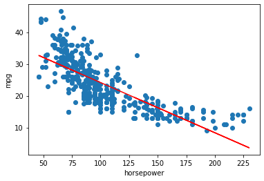

```python
plt.scatter(X,Y)
plt.xlabel('horsepower')
plt.ylabel('mpg')
plt.plot(X, Auto_mpg_simpreg.fittedvalues, color='red')
plt.show()
```

**8.(c)** Use the plot() function to produce diagnostic plots of the least squares regression fit. Comment on any problems you see with the fit.

> We will create two graphs: one fitted values vs residuals and the other standardized (or studentized) vs residuals. To graph the (externally) studentized we will use the statsmodels library's influence_plot. There are internal and external studentization. When considering an ith case to be an outlier we use external. For a detailed approach see the Examples section (particularly, the Regression Plots subsection) at www.statsmodels.org

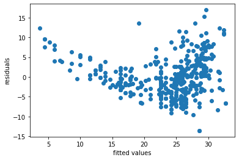

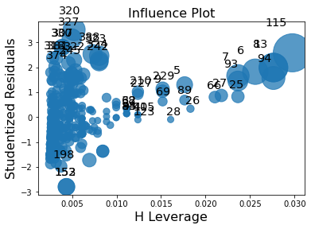

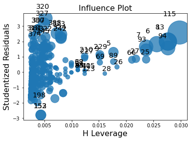

```python
plt.scatter(Auto_mpg_simpreg.fittedvalues, Auto_mpg_simpreg.resid)
plt.xlabel('fitted values')
plt.ylabel('residuals')
plt.show()
sm.graphics.influence_plot(Auto_mpg_simpreg)
```

> Section 3.3.3. discusses the diagnostics (the Lab notes I posted also reproduce the key points). From the top residuals graph we can immediately see the non-linearity of this data (since there is a clear pattern in the residuals, in this case its a bit like a U-shape) and heteroskedasticity (since there is a conical pattern).

> The bottom right graph indicates a high leverage point at 115.

# 9. Multiple LR & Diagnostics

This question involves the use of multiple linear regression on the Auto data set. Produce a scatterplot matrix which includes all of the variables in the data set.

**9.(a)** Produce a scatterplot matrix which includes all of the variables in the data set.

> The easiest way is to use seaborn which is built on top of matplotlib.

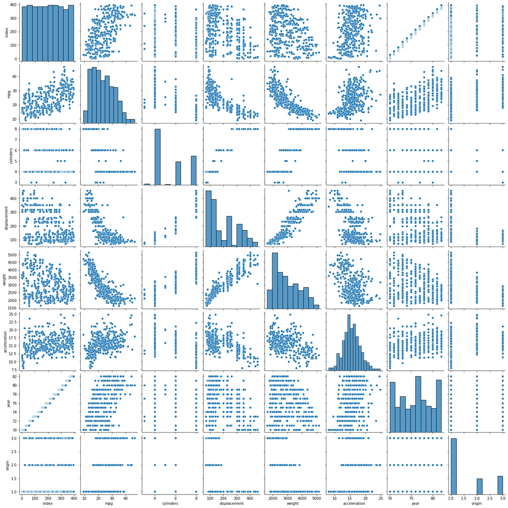

```python
import seaborn as sns
sns.pairplot(Auto_data)
```

**9.(b)**

Compute the matrix of correlations between the variables using the function corr(). You will need to exclude the name variable, which is qualitative.

```python
corr = Auto_data.corr()
corr
```

|  | index | mpg | cylinders | displacement | weight | acceleration | year | origin |
| --- | --- | --- | --- | --- | --- | --- | --- | --- |
| index | 1.000000 | 0.586330 | -0.360275 | -0.387146 | -0.321747 | 0.290985 | 0.996780 | 0.200576 |
| mpg | 0.586330 | 1.000000 | -0.777618 | -0.805127 | -0.832244 | 0.423329 | 0.580541 | 0.565209 |
| cylinders | -0.360275 | -0.777618 | 1.000000 | 0.950823 | 0.897527 | -0.504683 | -0.345647 | -0.568932 |
| displacement | -0.387146 | -0.805127 | 0.950823 | 1.000000 | 0.932994 | -0.543800 | -0.369855 | -0.614535 |
| weight | -0.321747 | -0.832244 | 0.897527 | 0.932994 | 1.000000 | -0.416839 | -0.309120 | -0.585005 |
| acceleration | 0.290985 | 0.423329 | -0.504683 | -0.543800 | -0.416839 | 1.000000 | 0.290316 | 0.212746 |
| year | 0.996780 | 0.580541 | -0.345647 | -0.369855 | -0.309120 | 0.290316 | 1.000000 | 0.181528 |
| origin | 0.200576 | 0.565209 | -0.568932 | -0.614535 | -0.585005 | 0.212746 | 0.181528 | 1.000000 |

> We can also use a heatmap function from the seaborn library to look at correlation heatmap.

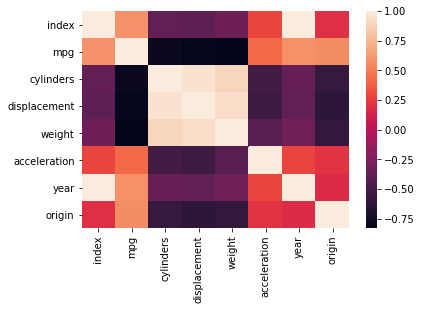

```python
sns.heatmap(corr)
```

**9.(c)** Perform a multiple linear regression with mpg as the response and all other variables except name as the predictors. Use the summary() function to print the results. Comment on the output.

> We can use the same approach as we used for simple regression with statsmodels' OLS function where we introduced a constant.  
> Here we can try a slightly different approach, the syntax of which is a bit closer to R. For this, we will need to import statsmodels' formula api first.  
> Also remember 'horsepower' needs to be converted to a float. Otherwise we will get all kinds of weird and wonderful summary.

```python
import statsmodels.formula.api as smf
Auto_data['horsepower'] = Auto_data['horsepower'].astype(np.float_)
Auto_mpg_multireg = smf.ols('mpg ~ cylinders + displacement + horsepower + weight + acceleration + year + origin', data=Auto_data).fit()
print(Auto_mpg_multireg.summary())
```

```
                            OLS Regression Results
==============================================================================
Dep. Variable:                    mpg   R-squared:                       0.821
Model:                            OLS   Adj. R-squared:                  0.818
Method:                 Least Squares   F-statistic:                     252.4
Date:                Sat, 23 Jan 2021   Prob (F-statistic):          2.04e-139
Time:                        17:01:22   Log-Likelihood:                -1023.5
No. Observations:                 392   AIC:                             2063.
Df Residuals:                     384   BIC:                             2095.
Df Model:                           7
Covariance Type:            nonrobust
================================================================================
                   coef    std err          t      P>|t|      [0.025      0.975]
--------------------------------------------------------------------------------
Intercept      -17.2184      4.644     -3.707      0.000     -26.350      -8.087
cylinders       -0.4934      0.323     -1.526      0.128      -1.129       0.142
displacement     0.0199      0.008      2.647      0.008       0.005       0.035
horsepower      -0.0170      0.014     -1.230      0.220      -0.044       0.010
weight          -0.0065      0.001     -9.929      0.000      -0.008      -0.005
acceleration     0.0806      0.099      0.815      0.415      -0.114       0.275
year             0.7508      0.051     14.729      0.000       0.651       0.851
origin           1.4261      0.278      5.127      0.000       0.879       1.973
==============================================================================
Omnibus:                       31.906   Durbin-Watson:                   1.309
Prob(Omnibus):                  0.000   Jarque-Bera (JB):               53.100
Skew:                           0.529   Prob(JB):                     2.95e-12
Kurtosis:                       4.460   Cond. No.                     8.59e+04
==============================================================================

Notes:
[1] Standard Errors assume that the covariance matrix of the errors is correctly specified.
[2] The condition number is large, 8.59e+04. This might indicate that there are
strong multicollinearity or other numerical problems.
```

> *9.(c)i.* Is there a relationship between the predictors and the response?

> > For the simple linear regression (eg, mpg vs horsepower above) we checked whether $\beta_1 = 0$ or not. In a multiple regression, we check if all the variables are different from 0 to find out if there is a relationship between the predictors and the response. Accoringly, the null and alternative hyopthesis are:  
> > $H_0 : \beta_1 = \beta_2 = ...=\beta_p = 0$ and $H_a :$ at least one $\beta_j$ is non-zero.  
> > We use F-statistic to test for this, where $F = \frac {\frac {(TSS-RSS)}{p}}{\frac {RSS}{(n-p-1)}}$  
> > To be able to reject the null we would look for an F-stat greater than 1. If the F-stat is close to 1 we would fail to reject the null (though how close to 1 depends on the values of n and p. See Section 3.2.2 for details).  
> > In this regression the F-stat is 252.4, and the probability of observing any value greater than or equal to F-stat is virtually 0 (ie the p-value < 2.2e-16) so we can comfortably reject the null and conclude that there is a relationship between at least one of the predictors and mpg.

> *9.(c)ii.* Which predictors appear to have a statistically significant relationship to the response?

> > Based on the p-values of each of the predictors, we can see that for cylinders, horsepower and acceleration we cannot reject the null hypothesis that they are different from 0. For weight, year and origin we can reject the null and state that there is a likely statistically significant relationship. Finally, the null hypothesis for displacement can be rejected at p=0.01 but not at p=0.005.

> *9.(c)iii.* What does the coefficient for the year variable suggest?

> > The coefficient for the year indicates that, holding all else the same, 1 year increase (ie as the cars get younger), on average, translates into an additional 0.75 miles per gallon.

**9.(d)** Use the plot() function to produce diagnostic plots of the linear regression fit. Comment on any problems you see with the fit. Do the residual plots suggest any unusually large outliers? Does the leverage plot identify any observations with unusually high leverage?

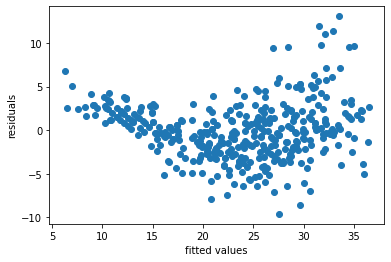

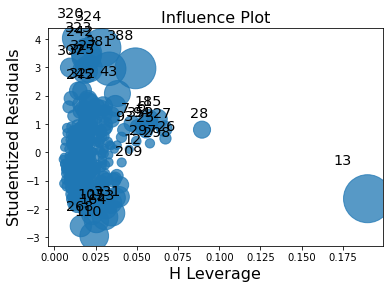

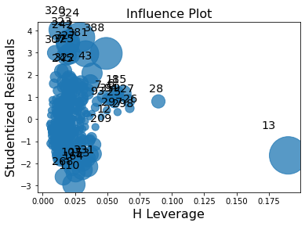

```python
plt.scatter(Auto_mpg_multireg.fittedvalues, Auto_mpg_multireg.resid)
plt.xlabel('fitted values')
plt.ylabel('residuals')
plt.show()
sm.graphics.influence_plot(Auto_mpg_multireg)
```

> Off the bat we can identify the presence of some non-linearity and heteroskedasticity from the top graph. We can also see a high leverage at point 13 in the bottom graph. But it is not an outlier since its within -2 standardized residuals.

**9.(e)** Fit linear regression models with interaction effects. Do any interactions appear to be statistically significant?

> Lets try all the interaction effects together.

```python
Auto_mpg_interactreg = smf.ols('mpg ~ cylinders + displacement + horsepower + weight + acceleration + year + origin + cylinders*displacement  + cylinders*horsepower + cylinders*weight + cylinders*acceleration + cylinders*year + cylinders*origin + displacement*horsepower + displacement*weight + displacement*acceleration + displacement*year + displacement*origin + horsepower*weight + horsepower*acceleration + horsepower*year + horsepower*origin + weight*acceleration + weight*year + weight*origin + acceleration*year + acceleration*origin + year*origin', data=Auto_data).fit()
print(Auto_mpg_interactreg.summary())
```

```
                            OLS Regression Results
==============================================================================
Dep. Variable:                    mpg   R-squared:                       0.889
Model:                            OLS   Adj. R-squared:                  0.881
Method:                 Least Squares   F-statistic:                     104.2
Date:                Sat, 23 Jan 2021   Prob (F-statistic):          4.01e-155
Time:                        17:01:36   Log-Likelihood:                -929.72
No. Observations:                 392   AIC:                             1917.
Df Residuals:                     363   BIC:                             2033.
Df Model:                          28
Covariance Type:            nonrobust
=============================================================================================
                                coef    std err          t      P>|t|      [0.025      0.975]
---------------------------------------------------------------------------------------------
Intercept                    35.4789     53.136      0.668      0.505     -69.014     139.972
cylinders                     6.9886      8.248      0.847      0.397      -9.231      23.208
displacement                 -0.4785      0.189     -2.527      0.012      -0.851      -0.106
horsepower                    0.5034      0.347      1.451      0.148      -0.179       1.186
weight                        0.0041      0.018      0.235      0.814      -0.030       0.039
acceleration                 -5.8592      2.174     -2.696      0.007     -10.134      -1.585
year                          0.6974      0.610      1.144      0.253      -0.501       1.896
origin                      -20.8956      7.097     -2.944      0.003     -34.852      -6.939
cylinders:displacement       -0.0034      0.006     -0.524      0.601      -0.016       0.009
cylinders:horsepower          0.0116      0.024      0.480      0.632      -0.036       0.059
cylinders:weight              0.0004      0.001      0.399      0.690      -0.001       0.002
cylinders:acceleration        0.2779      0.166      1.670      0.096      -0.049       0.605
cylinders:year               -0.1741      0.097     -1.793      0.074      -0.365       0.017
cylinders:origin              0.4022      0.493      0.816      0.415      -0.567       1.371
displacement:horsepower   -8.491e-05      0.000     -0.294      0.769      -0.001       0.000
displacement:weight        2.472e-05   1.47e-05      1.682      0.093   -4.18e-06    5.36e-05
displacement:acceleration    -0.0035      0.003     -1.041      0.299      -0.010       0.003
displacement:year             0.0059      0.002      2.482      0.014       0.001       0.011
displacement:origin           0.0240      0.019      1.232      0.219      -0.014       0.062
horsepower:weight         -1.968e-05   2.92e-05     -0.673      0.501   -7.72e-05    3.78e-05
horsepower:acceleration      -0.0072      0.004     -1.939      0.053      -0.015       0.000
horsepower:year              -0.0058      0.004     -1.482      0.139      -0.014       0.002
horsepower:origin             0.0022      0.029      0.076      0.939      -0.055       0.060
weight:acceleration           0.0002      0.000      1.025      0.306      -0.000       0.001
weight:year                  -0.0002      0.000     -1.056      0.292      -0.001       0.000
weight:origin                -0.0006      0.002     -0.364      0.716      -0.004       0.003
acceleration:year             0.0556      0.026      2.174      0.030       0.005       0.106
acceleration:origin           0.4583      0.157      2.926      0.004       0.150       0.766
year:origin                   0.1393      0.074      1.882      0.061      -0.006       0.285
==============================================================================
Omnibus:                       47.137   Durbin-Watson:                   1.664
Prob(Omnibus):                  0.000   Jarque-Bera (JB):              116.060
Skew:                           0.600   Prob(JB):                     6.28e-26
Kurtosis:                       5.380   Cond. No.                     3.76e+08
==============================================================================

Notes:
[1] Standard Errors assume that the covariance matrix of the errors is correctly specified.
[2] The condition number is large, 3.76e+08. This might indicate that there are
strong multicollinearity or other numerical problems.
```

> Let's then compare the adjusted R-squares of the two models. (We are comparing the *adjusted* R-squares because the regular R-squared will increase simply by adding more variables.) The adjusted R-squared is 88.1% with the interaction terms compared to 81.8% without the interaction terms. This means:

```python
(88.1-81.8)/(100-81.8)
```

```
0.3461538461538459
```

> about 34.6% of variability in mpg remaining after fitting the additive model (ie without the interactions) is explained by the interactions.  
> Of course not all the interactions are statistically significant. In fact acceleration:origin is the only one that is significant at p=0.01. acceleration:year and displacement:year are significant at 0.05, and cylinders:acceleration, cylinders:year, displacement:weight, horsepower:acceleration and year:origin are significant only at p=0.1.  
> Also note the presence of multicollinearity as identified in the correlation calculation and plot above (in part (b))  
> To improve the model, we can use the mixed selection method (see Section 3.2.2.) for variable selection to improve the model fit.

**9.(f)** Try a few different transformations of the variables, such as log(X), √X, X2. Comment on your findings.

```python
Auto_mpg_logreg = smf.ols('mpg ~ cylinders + displacement + horsepower + weight + acceleration + year + origin + np.log(displacement) + np.log(horsepower) + np.log(weight)', data=Auto_data).fit()
print(Auto_mpg_logreg.summary())
```

```
                            OLS Regression Results
==============================================================================
Dep. Variable:                    mpg   R-squared:                       0.864
Model:                            OLS   Adj. R-squared:                  0.861
Method:                 Least Squares   F-statistic:                     242.7
Date:                Sat, 23 Jan 2021   Prob (F-statistic):          1.85e-158
Time:                        17:09:16   Log-Likelihood:                -969.72
No. Observations:                 392   AIC:                             1961.
Df Residuals:                     381   BIC:                             2005.
Df Model:                          10
Covariance Type:            nonrobust
========================================================================================
                           coef    std err          t      P>|t|      [0.025      0.975]
----------------------------------------------------------------------------------------
Intercept              181.4133     39.818      4.556      0.000     103.123     259.704
cylinders               -0.1329      0.298     -0.446      0.656      -0.719       0.453
displacement             0.0107      0.014      0.752      0.452      -0.017       0.039
horsepower               0.1012      0.031      3.274      0.001       0.040       0.162
weight                   0.0018      0.002      0.832      0.406      -0.002       0.006
acceleration            -0.2126      0.100     -2.125      0.034      -0.409      -0.016
year                     0.7702      0.045     17.026      0.000       0.681       0.859
origin                   0.6282      0.268      2.341      0.020       0.101       1.156
np.log(displacement)    -2.4774      2.840     -0.872      0.384      -8.060       3.106
np.log(horsepower)     -17.3140      3.664     -4.725      0.000     -24.519     -10.109
np.log(weight)         -17.5163      7.194     -2.435      0.015     -31.661      -3.372
==============================================================================
Omnibus:                       33.708   Durbin-Watson:                   1.565
Prob(Omnibus):                  0.000   Jarque-Bera (JB):               68.415
Skew:                           0.486   Prob(JB):                     1.39e-15
Kurtosis:                       4.801   Cond. No.                     8.54e+05
==============================================================================

Notes:
[1] Standard Errors assume that the covariance matrix of the errors is correctly specified.
[2] The condition number is large, 8.54e+05. This might indicate that there are
strong multicollinearity or other numerical problems.
```

> The log transformed model's adjusted R-squared is 86.1% compared to 81.8% of the additive model. This means:

```python
(86.1-81.8)/(100-81.8)
```

```
0.23626373626373606
```

> 23.63% of the variability in mpg remaining after fitting the additive model is explained by the log transformations. This is not as strong as the interaction terms (which is expected as there is clear presence of multicollinearity) though still an improvement on the additive model.  
> We see that the coefficient of the horsepower log transformation is significantly different from 0 while this is also true for the log transformation of weight, albeit only at p=0.05 level.  
> Lets check the square root transformation next:

```python
Auto_mpg_sqrtreg = smf.ols('mpg ~ cylinders + displacement + horsepower + weight + acceleration + year + origin + np.sqrt(displacement) + np.sqrt(horsepower) + np.sqrt(weight)', data=Auto_data).fit()
print(Auto_mpg_sqrtreg.summary())
```

```
                            OLS Regression Results
==============================================================================
Dep. Variable:                    mpg   R-squared:                       0.865
Model:                            OLS   Adj. R-squared:                  0.861
Method:                 Least Squares   F-statistic:                     244.1
Date:                Sat, 23 Jan 2021   Prob (F-statistic):          7.24e-159
Time:                        17:13:48   Log-Likelihood:                -968.75
No. Observations:                 392   AIC:                             1960.
Df Residuals:                     381   BIC:                             2003.
Df Model:                          10
Covariance Type:            nonrobust
=========================================================================================
                            coef    std err          t      P>|t|      [0.025      0.975]
-----------------------------------------------------------------------------------------
Intercept                60.0028     10.786      5.563      0.000      38.795      81.210
cylinders                 0.0109      0.304      0.036      0.971      -0.587       0.609
displacement              0.0319      0.028      1.125      0.261      -0.024       0.088
horsepower                0.2458      0.063      3.875      0.000       0.121       0.370
weight                    0.0075      0.004      1.678      0.094      -0.001       0.016
acceleration             -0.2081      0.100     -2.075      0.039      -0.405      -0.011
year                      0.7696      0.045     17.048      0.000       0.681       0.858
origin                    0.6045      0.268      2.254      0.025       0.077       1.132
np.sqrt(displacement)    -1.0109      0.851     -1.188      0.236      -2.684       0.662
np.sqrt(horsepower)      -6.4739      1.430     -4.528      0.000      -9.285      -3.663
np.sqrt(weight)          -1.2641      0.522     -2.421      0.016      -2.291      -0.237
==============================================================================
Omnibus:                       35.134   Durbin-Watson:                   1.555
Prob(Omnibus):                  0.000   Jarque-Bera (JB):               71.518
Skew:                           0.505   Prob(JB):                     2.95e-16
Kurtosis:                       4.833   Cond. No.                     2.29e+05
==============================================================================

Notes:
[1] Standard Errors assume that the covariance matrix of the errors is correctly specified.
[2] The condition number is large, 2.29e+05. This might indicate that there are
strong multicollinearity or other numerical problems.
```

> There is a marginal improvement over the log model with the adjusted R-squared at 86.1%. The significance of the transformed variables is pretty much the same as the log transformations.  
> Finally, lets look at the squared transformations:

```python
Auto_mpg_sqreg = smf.ols('mpg ~ cylinders + displacement + horsepower + weight + acceleration + year + origin + np.power(displacement,2) + np.power(horsepower,2) + np.power(weight,2)', data=Auto_data).fit()
print(Auto_mpg_sqreg.summary())
```

```
                            OLS Regression Results
==============================================================================
Dep. Variable:                    mpg   R-squared:                       0.865
Model:                            OLS   Adj. R-squared:                  0.862
Method:                 Least Squares   F-statistic:                     244.8
Date:                Sat, 23 Jan 2021   Prob (F-statistic):          4.35e-159
Time:                        17:16:51   Log-Likelihood:                -968.23
No. Observations:                 392   AIC:                             1958.
Df Residuals:                     381   BIC:                             2002.
Df Model:                          10
Covariance Type:            nonrobust
=============================================================================================
                                coef    std err          t      P>|t|      [0.025      0.975]
---------------------------------------------------------------------------------------------
Intercept                     3.5087      4.789      0.733      0.464      -5.908      12.925
cylinders                     0.4113      0.327      1.256      0.210      -0.233       1.055
displacement                 -0.0351      0.020     -1.752      0.081      -0.075       0.004
horsepower                   -0.1915      0.041     -4.675      0.000      -0.272      -0.111
weight                       -0.0107      0.003     -4.122      0.000      -0.016      -0.006
acceleration                 -0.1735      0.100     -1.728      0.085      -0.371       0.024
year                          0.7692      0.045     17.048      0.000       0.680       0.858
origin                        0.5788      0.267      2.170      0.031       0.054       1.103
np.power(displacement, 2)  6.324e-05   3.46e-05      1.826      0.069   -4.86e-06       0.000
np.power(horsepower, 2)       0.0005      0.000      3.807      0.000       0.000       0.001
np.power(weight, 2)        1.047e-06   3.49e-07      3.002      0.003    3.61e-07    1.73e-06
==============================================================================
Omnibus:                       39.762   Durbin-Watson:                   1.519
Prob(Omnibus):                  0.000   Jarque-Bera (JB):               81.341
Skew:                           0.566   Prob(JB):                     2.17e-18
Kurtosis:                       4.923   Cond. No.                     3.61e+08
==============================================================================

Notes:
[1] Standard Errors assume that the covariance matrix of the errors is correctly specified.
[2] The condition number is large, 3.61e+08. This might indicate that there are
strong multicollinearity or other numerical problems.
```

> This model is also a slight improvement on both log and sqrt transformations with the adusted R-square of 86.2%.  
> In addition to the statistically significant variables in the other models, in this model weight variable is statistically significant and its squared transformation is also statistically significant at p=0.01. Similarly, displacement and its squared transformation are statistically significant only at p=0.1.

# 10. Multiple LR & Prediction

This question should be answered using the Carseats data set. (It is within the ISLR library.)

> Carseats dataset was not available on the book's website, so I loaded it up on R and then exported it. It is available as a csv file on [my github](https://e-usenmez.github.io/ISL/Data/).

```python
Carseats_df = pd.read_csv('~/.../Data/Carseats.csv')
Carseats_df.tail()
```

|  | Unnamed: 0 | Sales | CompPrice | Income | Advertising | Population | Price | ShelveLoc | Age | Education | Urban | US |
| --- | --- | --- | --- | --- | --- | --- | --- | --- | --- | --- | --- | --- |
| 395 | 396 | 12.57 | 138 | 108 | 17 | 203 | 128 | Good | 33 | 14 | Yes | Yes |
| 396 | 397 | 6.14 | 139 | 23 | 3 | 37 | 120 | Medium | 55 | 11 | No | Yes |
| 397 | 398 | 7.41 | 162 | 26 | 12 | 368 | 159 | Medium | 40 | 18 | Yes | Yes |
| 398 | 399 | 5.94 | 100 | 79 | 7 | 284 | 95 | Bad | 50 | 12 | Yes | Yes |
| 399 | 400 | 9.71 | 134 | 37 | 0 | 27 | 120 | Good | 49 | 16 | Yes | Yes |

**10(a)** Fit a multiple regression model to predict Sales using Price, Urban, and US.

```python
Carseats_multireg = smf.ols('Sales ~ Price + Urban + US', data = Carseats_df).fit()
print(Carseats_multireg.summary())
```

```
                            OLS Regression Results
==============================================================================
Dep. Variable:                  Sales   R-squared:                       0.239
Model:                            OLS   Adj. R-squared:                  0.234
Method:                 Least Squares   F-statistic:                     41.52
Date:                Sun, 24 Jan 2021   Prob (F-statistic):           2.39e-23
Time:                        10:08:24   Log-Likelihood:                -927.66
No. Observations:                 400   AIC:                             1863.
Df Residuals:                     396   BIC:                             1879.
Df Model:                           3
Covariance Type:            nonrobust
================================================================================
                   coef    std err          t      P>|t|      [0.025      0.975]
--------------------------------------------------------------------------------
Intercept       13.0435      0.651     20.036      0.000      11.764      14.323
Urban[T.Yes]    -0.0219      0.272     -0.081      0.936      -0.556       0.512
US[T.Yes]        1.2006      0.259      4.635      0.000       0.691       1.710
Price           -0.0545      0.005    -10.389      0.000      -0.065      -0.044
==============================================================================
Omnibus:                        0.676   Durbin-Watson:                   1.912
Prob(Omnibus):                  0.713   Jarque-Bera (JB):                0.758
Skew:                           0.093   Prob(JB):                        0.684
Kurtosis:                       2.897   Cond. No.                         628.
==============================================================================

Notes:
[1] Standard Errors assume that the covariance matrix of the errors is correctly specified.
```

**10(b)** Provide an interpretation of each coefficient in the model. Be careful—some of the variables in the model are qualitative!

> Price for car seats has a negative statistically significant relationship with carseat sales. For each unit increase in the price, the sales decline on average by about 54.5 car seats.  
> The regression created 2 dummy variables: UrbanT.Yes and UST.Yes. The former takes a value of 1 if the store is in an urban area and 0 if in a rural location. The latter takes a value of 1 if the store is in the US and 0 if not.  
> The negative sign of UrbanT.Yes indicate that a store in an urban location is associated with lower sales compared to a store in a rural location. However, it is not statistically significant, ie we can't reject the null that this coefficient is different from 0.  
> The positive sign for UST.Yes indicate that a store located in the US is associated with higher sales compared to non-US stores, with, on averge, an additional 1200.6 seats. This is statistically significant.

**10.(c)** Write out the model in equation form, being careful to handle the qualitative variables properly.

**10.(d)** For which of the predictors can you reject the null hypothesis $H_0 : \beta_j = 0$?

> We can reject the null for Price and US predictors.

**10.(e)** On the basis of your response to the previous question, fit a smaller model that only uses the predictors for which there is evidence of association with the outcome.

```python
Carseats_smreg = smf.ols('Sales ~ Price + US', data = Carseats_df).fit()
print(Carseats_smreg.summary())
```

```
                            OLS Regression Results
==============================================================================
Dep. Variable:                  Sales   R-squared:                       0.239
Model:                            OLS   Adj. R-squared:                  0.235
Method:                 Least Squares   F-statistic:                     62.43
Date:                Sun, 24 Jan 2021   Prob (F-statistic):           2.66e-24
Time:                        10:08:45   Log-Likelihood:                -927.66
No. Observations:                 400   AIC:                             1861.
Df Residuals:                     397   BIC:                             1873.
Df Model:                           2
Covariance Type:            nonrobust
==============================================================================
                 coef    std err          t      P>|t|      [0.025      0.975]
------------------------------------------------------------------------------
Intercept     13.0308      0.631     20.652      0.000      11.790      14.271
US[T.Yes]      1.1996      0.258      4.641      0.000       0.692       1.708
Price         -0.0545      0.005    -10.416      0.000      -0.065      -0.044
==============================================================================
Omnibus:                        0.666   Durbin-Watson:                   1.912
Prob(Omnibus):                  0.717   Jarque-Bera (JB):                0.749
Skew:                           0.092   Prob(JB):                        0.688
Kurtosis:                       2.895   Cond. No.                         607.
==============================================================================

Notes:
[1] Standard Errors assume that the covariance matrix of the errors is correctly specified.
```

**10.(f)** How well do the models in (a) and (e) fit the data?

> There is a marginal improvement over the model that includes the Urban variable. While the model in (a) explains 23.4% of the varibility in car seat sales, the model without the Urban variable can explain 23.5% of that variability.

**10.(g)** Using the model from (e), obtain 95% confidence intervals for the coefficient(s).

**10.(h)** Is there evidence of outliers or high leverage observations in the model from (e)?

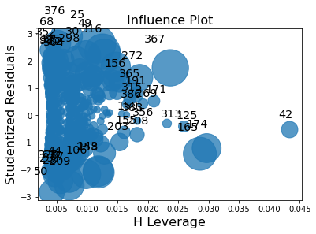

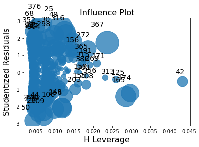

```python
sm.graphics.influence_plot(Carseats_smreg)
```

> we can see that all residuals are within -3 and 3, so there aren't any outliers but the data point 42 shows a high leverage.  
> We can also use a different plot from statsmodels library that scatterplots leverage vs normalized residuals$^2$:

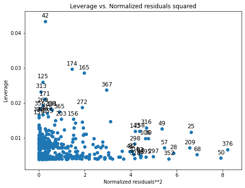

```python
from statsmodels.graphics.regressionplots import plot_leverage_resid2
fig, ax = plt.subplots(figsize=(8,6))
fig = plot_leverage_resid2(Carseats_smreg, ax = ax)
```

# 11. Simple LR (w/o Intercept) & Significance

In this problem we will investigate the t-statistic for the null hypothesis $H_0 : \beta = 0$ in simple linear regression without an intercept. To begin, we generate a predictor x and a response y as follows.

```python
np.random.seed(1)
x = np.random.normal(size=100)
y = 2*x + np.random.normal(size=100)
```

**11.(a)** Perform a simple linear regression of y onto x, without an intercept. Report the coefficient estimate $\hat\beta$, the standard error of this coefficient estimate, and the t-statistic and p-value associated with the null hypothesis $H_0 : \beta = 0$. Comment on these results.

> In Question 8.(a), when we carried out a simple regression with statsmodels.api we added a constant. Here we don't have to since we will regress this function without an intercept. Alternatively we can use the statsmodels.formula.api (smf) as well. Before we can do so, however, first we need to put the x and y we created into a dataframe.

```python
df_11 = pd.DataFrame({'x':x, 'y':y})
eleven_a_model = sm.OLS(df_11.y, df_11.x).fit()
print(eleven_a_model.summary())
```

```
                                 OLS Regression Results
=======================================================================================
Dep. Variable:                      y   R-squared (uncentered):                   0.798
Model:                            OLS   Adj. R-squared (uncentered):              0.796
Method:                 Least Squares   F-statistic:                              391.7
Date:                Sun, 24 Jan 2021   Prob (F-statistic):                    3.46e-36
Time:                        10:43:03   Log-Likelihood:                         -135.67
No. Observations:                 100   AIC:                                      273.3
Df Residuals:                      99   BIC:                                      275.9
Df Model:                           1
Covariance Type:            nonrobust
==============================================================================
                 coef    std err          t      P>|t|      [0.025      0.975]
------------------------------------------------------------------------------
x              2.1067      0.106     19.792      0.000       1.896       2.318
==============================================================================
Omnibus:                        0.880   Durbin-Watson:                   2.106
Prob(Omnibus):                  0.644   Jarque-Bera (JB):                0.554
Skew:                          -0.172   Prob(JB):                        0.758
Kurtosis:                       3.119   Cond. No.                         1.00
==============================================================================

Notes:
[1] R² is computed without centering (uncentered) since the model does not contain a constant.
[2] Standard Errors assume that the covariance matrix of the errors is correctly specified.
```

> Alternatively, we can use the statsmodels.formula.api (smf) to get the same output. Here we need to add -1 to the tell it to remove the constant (intercept):

```python
eleven_a_smf = smf.ols('y ~ x -1', data=df_11).fit()
print(eleven_a_smf.summary())
```

```
                                 OLS Regression Results
=======================================================================================
Dep. Variable:                      y   R-squared (uncentered):                   0.798
Model:                            OLS   Adj. R-squared (uncentered):              0.796
Method:                 Least Squares   F-statistic:                              391.7
Date:                Sun, 24 Jan 2021   Prob (F-statistic):                    3.46e-36
Time:                        10:47:16   Log-Likelihood:                         -135.67
No. Observations:                 100   AIC:                                      273.3
Df Residuals:                      99   BIC:                                      275.9
Df Model:                           1
Covariance Type:            nonrobust
==============================================================================
                 coef    std err          t      P>|t|      [0.025      0.975]
------------------------------------------------------------------------------
x              2.1067      0.106     19.792      0.000       1.896       2.318
==============================================================================
Omnibus:                        0.880   Durbin-Watson:                   2.106
Prob(Omnibus):                  0.644   Jarque-Bera (JB):                0.554
Skew:                          -0.172   Prob(JB):                        0.758
Kurtosis:                       3.119   Cond. No.                         1.00
==============================================================================

Notes:
[1] R² is computed without centering (uncentered) since the model does not contain a constant.
[2] Standard Errors assume that the covariance matrix of the errors is correctly specified.
```

> Both summary outputs are the same. The coefficient estimate is 2.1067 with a std. err. of 0.106, t-stat of 19.792, a p-value of 0 and a 95% CI of (1,896, 2.318). As before, we can conclude that there is a statistically significant relationship between the predictor and the response, whereby a unit increase in x corresponds to a 2.1067 increase in y on average, and that this estimate differs from the actual value on average by 0.106.

**11.(b)** Now perform a simple linear regression of x onto y without an intercept, and report the coefficient estimate, its standard error, and the corresponding t-statistic and p-values associated with the null hypothesis $H_0 : \beta = 0$. Comment on these results.

```python
eleven_b_model = sm.OLS(df_11.x, df_11.y).fit()
print(eleven_b_model.summary())
```

```
                                 OLS Regression Results
=======================================================================================
Dep. Variable:                      x   R-squared (uncentered):                   0.798
Model:                            OLS   Adj. R-squared (uncentered):              0.796
Method:                 Least Squares   F-statistic:                              391.7
Date:                Sun, 24 Jan 2021   Prob (F-statistic):                    3.46e-36
Time:                        10:52:12   Log-Likelihood:                         -49.891
No. Observations:                 100   AIC:                                      101.8
Df Residuals:                      99   BIC:                                      104.4
Df Model:                           1
Covariance Type:            nonrobust
==============================================================================
                 coef    std err          t      P>|t|      [0.025      0.975]
------------------------------------------------------------------------------
y              0.3789      0.019     19.792      0.000       0.341       0.417
==============================================================================
Omnibus:                        0.476   Durbin-Watson:                   2.166
Prob(Omnibus):                  0.788   Jarque-Bera (JB):                0.631
Skew:                           0.115   Prob(JB):                        0.729
Kurtosis:                       2.685   Cond. No.                         1.00
==============================================================================

Notes:
[1] R² is computed without centering (uncentered) since the model does not contain a constant.
[2] Standard Errors assume that the covariance matrix of the errors is correctly specified.
```

> The coefficient estimate is 0.3789 with a std. err. of 0.019, t-stat of 19.792, a p-value of 0 and a 95% CI of (0.341, 0.417). As before, we can conclude that there is a statistically significant relationship between the predictor and the response, whereby a unit increase in y corresponds to a 0.3789 increase in x on average, and that this estimate differs from the actual value on average by 0.019.

**11.(c)** What is the relationship between the results obtained in (a) and (b)?

> In both models R-squared and the t-stats (thus their p-values too) are the same. This is expected as the models are inverse of each other and since they are the only variable in explaining the other, they ought to explain the same amount of variability in each other. Similarly, and for the same reasons, the t-stat that measures the number of st.devs the variable is away from 0 would have to be the same too.

For the regression of Y onto X without an intercept, the t-statistic for $H_0 : \beta = 0$ takes the form $\frac{\hat\beta}{SE(\hat\beta)}$, where $\hat\beta$ is given by (3.38), and where

$SE(\hat\beta) = \sqrt\frac{\sum_{i=1}^n(y_i-x_i\hat\beta)^2}{(n-1)\sum_{i^{'}=1}^nx_{i^{'}}^2}$

(These formulas are slightly different from those given in Sections 3.1.1 and 3.1.2, since here we are performing regression without an intercept.) Show algebraically, and confirm numerically in R, that the t-statistic can be written as

$\frac{(\sqrt (n-1))\sum_{i=1}^n x_iy_i}{\sqrt ((\sum_{i=1}^nx_i^2)(\sum_{i^{'}=1}^n y_{i^{'}}^2)-(\sum_{i^{'}=1}^n x_{i^{'}}y_{i^{'}})^2)}$

> Equation 3.38 is given in Question 5 where,

> $\hat\beta = \frac{(\sum\limits_{i=1}^n{x_iy_i})}{\sum\limits_{i^{'}=1}^{n}{x_{i^{'}}^2}}$

> Since t-stat without an intercept takes the form:

> $\frac{\hat\beta}{SE(\hat\beta)} = \frac{\frac{\sum\limits_{i=1}^n{x_iy_i}}{\sum\limits_{i^{'}=1}^{n}{x_{i^{'}}^2}}}{\sqrt\frac{\sum_{i=1}^n(y_i-x_i\hat\beta)^2}{(n-1)\sum_{i^{'}=1}^nx_{i^{'}}^2}} = \frac{\sum\limits_{i=1}^n{x_iy_i}}{\sum\limits_{i^{'}=1}^{n}{x_{i^{'}}^2}} \times \frac{\sqrt{n-1}\sqrt{\sum_{i^{'}=1}^nx_{i^{'}}^2}}{\sqrt{\sum_{i=1}^n(y_i-x_i\hat\beta)^2}} = \frac{\sum\limits_{i=1}^n{x_iy_i} \times \sqrt{n-1}}{\sqrt{\sum\limits_{i^{'}=1}^{n}{x_{i^{'}}^2}}\sqrt{\sum_{i=1}^n(y_i-x_i\hat\beta)^2}} = \frac{\sum\limits_{i=1}^n{x_iy_i} \times \sqrt{n-1}}{\sqrt{\sum\limits_{i^{'}=1}^{n}{x_{i^{'}}^2}}\sqrt{\sum_{i=1}^n(y_i^2+x_i^2\hat\beta^2-2y_ix_i\hat\beta)}}$

> If we then plug in the $\hat\beta$ into the denominator we get:

> $\frac{\sum\limits_{i=1}^n{x_iy_i} \times \sqrt{n-1}}{\sqrt{\sum\limits_{i^{'}=1}^{n}{x_{i^{'}}^2}}\sqrt{\sum_{i=1}^n(y_i^2+x_i^2(\frac{(\sum\limits_{i=1}^n{x_iy_i})}{\sum\limits_{i^{'}=1}^{n}{x_{i^{'}}^2}})^2-2y_ix_i(\frac{(\sum\limits_{i=1}^n{x_iy_i})}{\sum\limits_{i^{'}=1}^{n}{x_{i^{'}}^2}}))}} = \frac{\sqrt{n-1} \times \sum\limits_{i=1}^n{x_iy_i}}{\sqrt{(\sum_{i=1}^n x_i^2)(\sum\limits_{i^{'}=1}^{n}{y_{i^{'}}^2})-(\sum_{i^{'}}^nx_{i^{'}}y_{i{'}})^2}}$

> We can verify this in Python as well. n is the length of x in the first regression so:

```python
n = len(df_11.x)
np.sqrt(n-1)*np.sum(x*y)/np.sqrt(np.sum(np.power(x,2))*np.sum(np.power(y,2))-np.power(np.sum(x*y),2))
```

```
19.791801987091205
```

> Compare this to $\frac{\hat\beta}{SE(\hat\beta)} = \frac{\frac{\sum\limits_{i=1}^n{x_iy_i}}{\sum\limits_{i^{'}=1}^{n}{x_{i^{'}}^2}}}{\sqrt\frac{\sum_{i=1}^n(y_i-x_i\hat\beta)^2}{(n-1)\sum_{i^{'}=1}^nx_{i^{'}}^2}}$

```python
betahat = np.sum(x*y)/np.sum(np.power(x,2))
SEbetahat = np.sqrt(np.sum(np.power((y-x*betahat),2))/((n-1)*(np.sum(np.power(x,2)))))
betahat / SEbetahat
```

```
19.7918019870912
```

> Confirming that both gives us a t-value of 19.7918.

**11.(e)** Using the results from (d), argue that the t-statistic for the regression of y onto x is the same as the t-statistic for the regression of x onto y.

> The equation derived in (d) for t-statistic is the same irrespective of whether we regress y onto x or x onto y. Therefore, the t-stat would be the same regardless.

**11.(f)** Show that when regression is performed with an intercept, the t-statistic for $H_0 : \beta = 0$ is the same for the regression of y onto x as it is for the regression of x onto y.

```python
c = sm.add_constant(df_11.x)
eleven_f_model = sm.OLS(y, c).fit()
print(eleven_f_model.summary())
```

```
                            OLS Regression Results
==============================================================================
Dep. Variable:                      y   R-squared:                       0.800
Model:                            OLS   Adj. R-squared:                  0.798
Method:                 Least Squares   F-statistic:                     391.4
Date:                Sun, 24 Jan 2021   Prob (F-statistic):           5.39e-36
Time:                        11:25:38   Log-Likelihood:                -134.44
No. Observations:                 100   AIC:                             272.9
Df Residuals:                      98   BIC:                             278.1
Df Model:                           1
Covariance Type:            nonrobust
==============================================================================
                 coef    std err          t      P>|t|      [0.025      0.975]
------------------------------------------------------------------------------
const          0.1470      0.094      1.564      0.121      -0.039       0.334
x              2.0954      0.106     19.783      0.000       1.885       2.306
==============================================================================
Omnibus:                        0.898   Durbin-Watson:                   2.157
Prob(Omnibus):                  0.638   Jarque-Bera (JB):                0.561
Skew:                          -0.172   Prob(JB):                        0.755
Kurtosis:                       3.127   Cond. No.                         1.15
==============================================================================

Notes:
[1] Standard Errors assume that the covariance matrix of the errors is correctly specified.
```

> Now lets compare this with a regression of x onto y. This time we will use the smf api:

```python
eleven_f_smf = smf.ols('x ~ y', data=df_11).fit()
print(eleven_f_smf.summary())
```

```
                            OLS Regression Results
==============================================================================
Dep. Variable:                      x   R-squared:                       0.800
Model:                            OLS   Adj. R-squared:                  0.798
Method:                 Least Squares   F-statistic:                     391.4
Date:                Sun, 24 Jan 2021   Prob (F-statistic):           5.39e-36
Time:                        11:29:04   Log-Likelihood:                -49.289
No. Observations:                 100   AIC:                             102.6
Df Residuals:                      98   BIC:                             107.8
Df Model:                           1
Covariance Type:            nonrobust
==============================================================================
                 coef    std err          t      P>|t|      [0.025      0.975]
------------------------------------------------------------------------------
Intercept     -0.0440      0.040     -1.090      0.279      -0.124       0.036
y              0.3817      0.019     19.783      0.000       0.343       0.420
==============================================================================
Omnibus:                        0.456   Durbin-Watson:                   2.192
Prob(Omnibus):                  0.796   Jarque-Bera (JB):                0.611
Skew:                           0.118   Prob(JB):                        0.737
Kurtosis:                       2.698   Cond. No.                         2.12
==============================================================================

Notes:
[1] Standard Errors assume that the covariance matrix of the errors is correctly specified.
```

> Confirming that in both regressions the t-stat for $H_0 : \beta_1 = 0$ is the same at 19.783.

# 12. Simple LR w/o Intercept

This problem involves simple linear regression without an intercept.

**12.(a)** Recall that the coefficient estimate $\hat\beta$ for the linear regression of Y onto X without an intercept is given by (3.38). Under what circumstance is the coefficient estimate for the regression of X onto Y the same as the coefficient estimate for the regression of Y onto X?

> Since $\hat\beta_x = \frac{(\sum\limits_{i=1}^n{x_iy_i})}{\sum\limits_{i^{'}=1}^{n}{x_{i^{'}}^2}}$ and $\hat\beta_y = \frac{(\sum\limits_{i=1}^n{x_iy_i})}{\sum\limits_{i^{'}=1}^{n}{y_{i^{'}}^2}}$ the two can only be equal if the denominators are equal.  
> That is:

**12b(b)** Generate an example in R with n = 100 observations in which the coefficient estimate for the regression of X onto Y is different from the coefficient estimate for the regression of Y onto X.

```python
np.random.seed(1)
x = np.random.normal(size=100)
y = np.power(x,3) + np.random.normal(size=100)
df_12 = pd.DataFrame({'X': x, 'Y': y})
twelve_b_model = sm.OLS(df_12.Y, df_12.X).fit()
twelve_b_XYmodel = sm.OLS(df_12.X, df_12.Y).fit()
print(twelve_b_model.summary())
print(twelve_b_XYmodel.summary())
```

```
                                 OLS Regression Results
=======================================================================================
Dep. Variable:                      Y   R-squared (uncentered):                   0.590
Model:                            OLS   Adj. R-squared (uncentered):              0.586
Method:                 Least Squares   F-statistic:                              142.4
Date:                Sun, 24 Jan 2021   Prob (F-statistic):                    7.11e-21
Time:                        12:17:13   Log-Likelihood:                         -202.03
No. Observations:                 100   AIC:                                      406.1
Df Residuals:                      99   BIC:                                      408.7
Df Model:                           1
Covariance Type:            nonrobust
==============================================================================
                 coef    std err          t      P>|t|      [0.025      0.975]
------------------------------------------------------------------------------
X              2.4664      0.207     11.934      0.000       2.056       2.877
==============================================================================
Omnibus:                       10.359   Durbin-Watson:                   2.024
Prob(Omnibus):                  0.006   Jarque-Bera (JB):               25.059
Skew:                           0.161   Prob(JB):                     3.62e-06
Kurtosis:                       5.431   Cond. No.                         1.00
==============================================================================

Notes:
[1] R² is computed without centering (uncentered) since the model does not contain a constant.
[2] Standard Errors assume that the covariance matrix of the errors is correctly specified.
                                 OLS Regression Results
=======================================================================================
Dep. Variable:                      X   R-squared (uncentered):                   0.590
Model:                            OLS   Adj. R-squared (uncentered):              0.586
Method:                 Least Squares   F-statistic:                              142.4
Date:                Sun, 24 Jan 2021   Prob (F-statistic):                    7.11e-21
Time:                        12:17:13   Log-Likelihood:                         -85.359
No. Observations:                 100   AIC:                                      172.7
Df Residuals:                      99   BIC:                                      175.3
Df Model:                           1
Covariance Type:            nonrobust
==============================================================================
                 coef    std err          t      P>|t|      [0.025      0.975]
------------------------------------------------------------------------------
Y              0.2392      0.020     11.934      0.000       0.199       0.279
==============================================================================
Omnibus:                       15.611   Durbin-Watson:                   1.876
Prob(Omnibus):                  0.000   Jarque-Bera (JB):                4.397
Skew:                           0.023   Prob(JB):                        0.111
Kurtosis:                       1.974   Cond. No.                         1.00
==============================================================================

Notes:
[1] R² is computed without centering (uncentered) since the model does not contain a constant.
[2] Standard Errors assume that the covariance matrix of the errors is correctly specified.
```

**12.(c)** Generate an example in R with n = 100 observations in which the coefficient estimate for the regression of X onto Y is the same as the coefficient estimate for the regression of Y onto X.

```python
np.random.seed(1)
x = np.random.normal(size=100)
y = -np.random.choice(x, size=100, replace=False) #This effectively samples from x.
#By choosing the size 100 and not replacing the choice we effectively make this a randomly reordered x.
df_12 = pd.DataFrame({'X': x, 'Y': y})
twelve_c_model = sm.OLS(df_12.Y, df_12.X).fit()
twelve_c_XYmodel = sm.OLS(df_12.X, df_12.Y).fit()
print(twelve_c_model.summary())
print(twelve_c_XYmodel.summary())
```

```
                                 OLS Regression Results
=======================================================================================
Dep. Variable:                      Y   R-squared (uncentered):                   0.046
Model:                            OLS   Adj. R-squared (uncentered):              0.036
Method:                 Least Squares   F-statistic:                              4.778
Date:                Sun, 24 Jan 2021   Prob (F-statistic):                      0.0312
Time:                        12:30:25   Log-Likelihood:                         -127.57
No. Observations:                 100   AIC:                                      257.1
Df Residuals:                      99   BIC:                                      259.7
Df Model:                           1
Covariance Type:            nonrobust
==============================================================================
                 coef    std err          t      P>|t|      [0.025      0.975]
------------------------------------------------------------------------------
X             -0.2146      0.098     -2.186      0.031      -0.409      -0.020
==============================================================================
Omnibus:                        0.182   Durbin-Watson:                   1.983
Prob(Omnibus):                  0.913   Jarque-Bera (JB):                0.073
Skew:                           0.066   Prob(JB):                        0.964
Kurtosis:                       2.997   Cond. No.                         1.00
==============================================================================

Notes:
[1] R² is computed without centering (uncentered) since the model does not contain a constant.
[2] Standard Errors assume that the covariance matrix of the errors is correctly specified.
                                 OLS Regression Results
=======================================================================================
Dep. Variable:                      X   R-squared (uncentered):                   0.046
Model:                            OLS   Adj. R-squared (uncentered):              0.036
Method:                 Least Squares   F-statistic:                              4.778
Date:                Sun, 24 Jan 2021   Prob (F-statistic):                      0.0312
Time:                        12:30:25   Log-Likelihood:                         -127.57
No. Observations:                 100   AIC:                                      257.1
Df Residuals:                      99   BIC:                                      259.7
Df Model:                           1
Covariance Type:            nonrobust
==============================================================================
                 coef    std err          t      P>|t|      [0.025      0.975]
------------------------------------------------------------------------------
Y             -0.2146      0.098     -2.186      0.031      -0.409      -0.020
==============================================================================
Omnibus:                        0.028   Durbin-Watson:                   2.036
Prob(Omnibus):                  0.986   Jarque-Bera (JB):                0.155
Skew:                          -0.026   Prob(JB):                        0.926
Kurtosis:                       2.815   Cond. No.                         1.00
==============================================================================

Notes:
[1] R² is computed without centering (uncentered) since the model does not contain a constant.
[2] Standard Errors assume that the covariance matrix of the errors is correctly specified.
```

# 13. Simple LR on Simulated Data

In this exercise you will create some simulated data and will fit simple linear regression models to it. Make sure to use set.seed(1) prior to starting part (a) to ensure consistent results.

**13.(a)** Using the random.normal() function, create a vector, x, containing 100 observations drawn from a N(0,1) distribution. This represents a feature, X.

```python
np.random.seed(1)
X = np.random.normal(size=100)
```

**13.(b)** Using the rnorm() function, create a vector, eps, containing 100 observations drawn from a N(0,0.25) distribution i.e. a normal distribution with mean zero and variance 0.25.

```python
eps = np.random.normal(loc=0, scale=np.sqrt(0.25),size=100)
```

**13.(c)** Using x and eps, generate a vector y according to the model Y = −1 + 0.5X + $\varepsilon$

What is the length of the vector y? What are the values of $\beta_0$ and $\beta_1$ in this linear model?

> Y = -1 + 0.5*x + eps where the length of y is 100, $\beta_0 = -1, \beta_1 = 0.5$

```python
Y = -1 +0.5*X + eps
```

**13.(d)** Create a scatterplot displaying the relationship between x and y. Comment on what you observe.

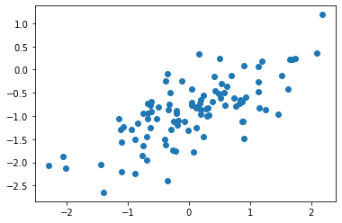

```python
plt.scatter(X, Y)
plt.show()
```

> There is a visible positive linear trend as expected.

**13.(e)** Fit a least squares linear model to predict y using x. Comment on the model obtained. How do $\hat\beta_0$ and $\hat\beta_1$ compare to $\beta_0$ and $\beta_1$?

```python
df_13 = pd.DataFrame({'X': X, 'Y':Y})
thirteen_e_model = smf.ols('Y ~ X', data=df_13).fit()
print(thirteen_e_model.summary())
```

```
                            OLS Regression Results
==============================================================================
Dep. Variable:                      Y   R-squared:                       0.522
Model:                            OLS   Adj. R-squared:                  0.517
Method:                 Least Squares   F-statistic:                     107.0
Date:                Sun, 24 Jan 2021   Prob (F-statistic):           2.20e-17
Time:                        14:23:06   Log-Likelihood:                -65.124
No. Observations:                 100   AIC:                             134.2
Df Residuals:                      98   BIC:                             139.5
Df Model:                           1
Covariance Type:            nonrobust
==============================================================================
                 coef    std err          t      P>|t|      [0.025      0.975]
------------------------------------------------------------------------------
Intercept     -0.9265      0.047    -19.717      0.000      -1.020      -0.833
X              0.5477      0.053     10.342      0.000       0.443       0.653
==============================================================================
Omnibus:                        0.898   Durbin-Watson:                   2.157
Prob(Omnibus):                  0.638   Jarque-Bera (JB):                0.561
Skew:                          -0.172   Prob(JB):                        0.755
Kurtosis:                       3.127   Cond. No.                         1.15
==============================================================================

Notes:
[1] Standard Errors assume that the covariance matrix of the errors is correctly specified.
```

> Both estimated values are quite close to the true values. $\hat\beta_0 = -0.9265$ is almost the same as $\beta_0 = -1$ and $\hat\beta_1 = 0.5477$ is pretty close to $\beta_1 = 0.5$. The 95% CI for $\beta_1$ is (0.443, 0.653).

**13.(f)** Display the least squares line on the scatterplot obtained in (d). Draw the population regression line on the plot, in a different color. Use the legend() command to create an appropriate legend.

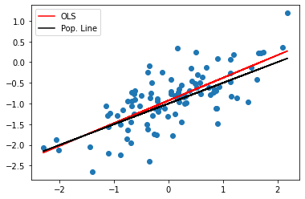

```python
plt.scatter(df_13.X, df_13.Y)
plt.plot(df_13.X, thirteen_e_model.fittedvalues, color='red', label = 'OLS')
plt.plot(df_13.X,-1+0.5*X, color='black', label = 'Pop. Line')
plt.legend(loc='upper left')
plt.show()
```

**13.(g)** Now fit a polynomial regression model that predicts y using x and x^2. Is there evidence that the quadratic term improves the model fit? Explain your answer.

```python
thirteen_polyreg = smf.ols('Y ~ X + np.power(X,2)', data=df_13).fit()
print(thirteen_polyreg.summary())
```

```
                            OLS Regression Results
==============================================================================
Dep. Variable:                      Y   R-squared:                       0.522
Model:                            OLS   Adj. R-squared:                  0.512
Method:                 Least Squares   F-statistic:                     52.96
Date:                Sun, 24 Jan 2021   Prob (F-statistic):           2.83e-16
Time:                        14:26:01   Log-Likelihood:                -65.107
No. Observations:                 100   AIC:                             136.2
Df Residuals:                      97   BIC:                             144.0
Df Model:                           2
Covariance Type:            nonrobust
==================================================================================
                     coef    std err          t      P>|t|      [0.025      0.975]
----------------------------------------------------------------------------------
Intercept         -0.9325      0.058    -16.158      0.000      -1.047      -0.818
X                  0.5468      0.053     10.229      0.000       0.441       0.653
np.power(X, 2)     0.0077      0.043      0.181      0.856      -0.077       0.092
==============================================================================
Omnibus:                        0.893   Durbin-Watson:                   2.152
Prob(Omnibus):                  0.640   Jarque-Bera (JB):                0.552
Skew:                          -0.170   Prob(JB):                        0.759
Kurtosis:                       3.132   Cond. No.                         2.10
==============================================================================

Notes:
[1] Standard Errors assume that the covariance matrix of the errors is correctly specified.
```

> Although the R-squared has remained the same at 52.2%, the adjusted R-square marginally decreased from 51.7% to 51.2%. In either way, we cannot state that the quadratic term improves the model. Not least because it is not statistically significant.

**13.(h)** Repeat (a)–(f) after modifying the data generation process in such a way that there is less noise in the data. The model (3.39) should remain the same. You can do this by decreasing the variance of the normal distribution used to generate the error term $\varepsilon$ in (b). Describe your results.

```python
eps = np.random.normal(loc=0, scale=np.sqrt(0.25/3),size=100)
Y = -1 +0.5*X + eps
df_13 = pd.DataFrame({'X': X, 'Y':Y})
thirteen_e_model = smf.ols('Y ~ X', data=df_13).fit()
print(thirteen_e_model.summary())
```

```
                            OLS Regression Results
==============================================================================
Dep. Variable:                      Y   R-squared:                       0.690
Model:                            OLS   Adj. R-squared:                  0.686
Method:                 Least Squares   F-statistic:                     217.7
Date:                Sun, 24 Jan 2021   Prob (F-statistic):           1.23e-26
Time:                        14:32:38   Log-Likelihood:                -18.076
No. Observations:                 100   AIC:                             40.15
Df Residuals:                      98   BIC:                             45.36
Df Model:                           1
Covariance Type:            nonrobust
==============================================================================
                 coef    std err          t      P>|t|      [0.025      0.975]
------------------------------------------------------------------------------
Intercept     -0.9964      0.029    -33.946      0.000      -1.055      -0.938
X              0.4881      0.033     14.754      0.000       0.422       0.554
==============================================================================
Omnibus:                        0.264   Durbin-Watson:                   2.186
Prob(Omnibus):                  0.876   Jarque-Bera (JB):                0.398
Skew:                           0.107   Prob(JB):                        0.820
Kurtosis:                       2.776   Cond. No.                         1.15
==============================================================================

Notes:
[1] Standard Errors assume that the covariance matrix of the errors is correctly specified.
```

> As expected, the reduction in the random error term's variance by a third has increased the R-squared from 52.2% to 69%. Ie, the model can explain more of the variability in y thanks to reduction in the random noise.

**13.(i)** Repeat (a)–(f) after modifying the data generation process in such a way that there is more noise in the data. The model (3.39) should remain the same. You can do this by increasing the variance of the normal distribution used to generate the error term ε in (b). Describe your results.

```python
eps = np.random.normal(loc=0, scale=np.sqrt(0.25*3),size=100)
Y = -1 +0.5*X + eps
df_13 = pd.DataFrame({'X': X, 'Y':Y})
thirteen_e_model = smf.ols('Y ~ X', data=df_13).fit()
print(thirteen_e_model.summary())
```

```
                            OLS Regression Results
==============================================================================
Dep. Variable:                      Y   R-squared:                       0.134
Model:                            OLS   Adj. R-squared:                  0.125
Method:                 Least Squares   F-statistic:                     15.20
Date:                Sun, 24 Jan 2021   Prob (F-statistic):           0.000177
Time:                        14:34:57   Log-Likelihood:                -133.36
No. Observations:                 100   AIC:                             270.7
Df Residuals:                      98   BIC:                             275.9
Df Model:                           1
Covariance Type:            nonrobust
==============================================================================
                 coef    std err          t      P>|t|      [0.025      0.975]
------------------------------------------------------------------------------
Intercept     -1.0121      0.093    -10.886      0.000      -1.197      -0.828
X              0.4085      0.105      3.898      0.000       0.201       0.616
==============================================================================
Omnibus:                        0.673   Durbin-Watson:                   2.042
Prob(Omnibus):                  0.714   Jarque-Bera (JB):                0.286
Skew:                           0.080   Prob(JB):                        0.867
Kurtosis:                       3.207   Cond. No.                         1.15
==============================================================================

Notes:
[1] Standard Errors assume that the covariance matrix of the errors is correctly specified.
```

> As expected, the 3-fold increase in the random error term's variance has decreased the R-squared from 52.2% to 13.4%. Ie, the model can explain smaller portion of the variability in y thanks to a much larger random noise.

**13.(j)** What are the confidence intervals for $\beta_0$ and $\beta_1$ based on the original data set, the noisier data set, and the less noisy data set? Comment on your results.

> When we look at the 95% CIs of the coefficients we see that the noisier the data, the wider the CI, and vice versa.

# 14. Collinearity

This problem focuses on the collinearity problem.

**14.(a)** Perform the following commands:

```python
np.random.seed(1)
x1 = np.random.uniform(size=100)
x2 = 0.5*x1 + np.random.normal(size=100)/10
y = 2 + 2*x1 + 0.3*x2 + np.random.normal(size=100)
```

The last line corresponds to creating a linear model in which y is a function of x1 and x2. Write out the form of the linear model. What are the regression coefficients?

> $y = 2 + 2\times x_1 + 0.3\times x_2 + \varepsilon$  
> The regression coefficients are:

```python
df_14 = pd.DataFrame({'x1': x1, 'x2': x2, 'y': y})
fourteen_a_model = smf.ols('y ~ x1 + x2', data=df_14).fit()
print(fourteen_a_model.params)
```

```
Intercept    2.189284
x1           0.704629
x2           2.502405
dtype: float64
```

> The regression coefficients are 0.7046 for x1 and 2.5024 for x2.

**14.(b)** What is the correlation between x1 and x2? Create a scatterplot displaying the relationship between the variables.

```
Correlation between x1 and x2 is 0.8390596222844917
```

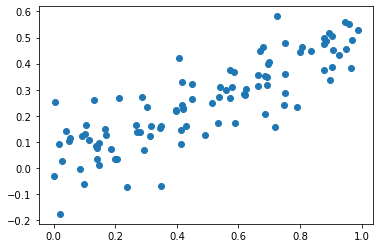

```python
corr_x1x2 = df_14.x1.corr(df_14.x2)
print('Correlation between x1 and x2 is', corr_x1x2)
plt.scatter(x1,x2)
plt.show()
```

> There is a strong positive correlation between the two at 0.839, which is further evidenced by the scatterplot.

**14.(c)** Using this data, fit a least squares regression to predict y using x1 and x2. Describe the results obtained. What are $\hat\beta_0, \hat\beta_1$, and $\hat\beta_2$? How do these relate to the true $\beta_0, \beta_1$, and $\beta_2$? Can you reject the null hypothesis $H_0 : \beta_1 = 0$? How about the null hypothesis $H_0 : \beta_2 = 0$?

```python
print(fourteen_a_model.summary())
```

```
                            OLS Regression Results
==============================================================================
Dep. Variable:                      y   R-squared:                       0.261
Model:                            OLS   Adj. R-squared:                  0.245
Method:                 Least Squares   F-statistic:                     17.09
Date:                Mon, 25 Jan 2021   Prob (F-statistic):           4.40e-07
Time:                        10:11:58   Log-Likelihood:                -142.34
No. Observations:                 100   AIC:                             290.7
Df Residuals:                      97   BIC:                             298.5
Df Model:                           2
Covariance Type:            nonrobust
==============================================================================
                 coef    std err          t      P>|t|      [0.025      0.975]
------------------------------------------------------------------------------
Intercept      2.1893      0.199     11.021      0.000       1.795       2.584
x1             0.7046      0.637      1.107      0.271      -0.559       1.968
x2             2.5024      1.140      2.194      0.031       0.239       4.766
==============================================================================
Omnibus:                        0.607   Durbin-Watson:                   2.111
Prob(Omnibus):                  0.738   Jarque-Bera (JB):                0.577
Skew:                          -0.179   Prob(JB):                        0.749
Kurtosis:                       2.900   Cond. No.                         14.3
==============================================================================

Notes:
[1] Standard Errors assume that the covariance matrix of the errors is correctly specified.
```

**14.(d)** Now fit a least squares regression to predict y using only x1. Comment on your results. Can you reject the null hypothesis $H_0 : \beta_1 = 0$?

```python
fourteen_d_model = smf.ols('y ~ x1', data=df_14).fit()
print(fourteen_d_model.summary())
```

```
                            OLS Regression Results
==============================================================================
Dep. Variable:                      y   R-squared:                       0.224
Model:                            OLS   Adj. R-squared:                  0.216
Method:                 Least Squares   F-statistic:                     28.26
Date:                Sun, 24 Jan 2021   Prob (F-statistic):           6.68e-07
Time:                        16:40:28   Log-Likelihood:                -144.76
No. Observations:                 100   AIC:                             293.5
Df Residuals:                      98   BIC:                             298.7
Df Model:                           1
Covariance Type:            nonrobust
==============================================================================
                 coef    std err          t      P>|t|      [0.025      0.975]
------------------------------------------------------------------------------
Intercept      2.2486      0.201     11.209      0.000       1.850       2.647
x1             1.8770      0.353      5.316      0.000       1.176       2.578
==============================================================================
Omnibus:                        0.292   Durbin-Watson:                   2.123
Prob(Omnibus):                  0.864   Jarque-Bera (JB):                0.468
Skew:                          -0.003   Prob(JB):                        0.791
Kurtosis:                       2.665   Cond. No.                         4.26
==============================================================================

Notes:
[1] Standard Errors assume that the covariance matrix of the errors is correctly specified.
```

> Although the R-squared of this regression and the previous one are roughly the same, the x1 is now statistically significant. This is expected since there is a strong collinearity between x1 and x2. Dropping x2 would not impact the R-squared that much while solving the collinearity problem. the p-value associated with $\beta_1$ is effectively 0, so we can comfortably reject the null.

**14.(e)** Now fit a least squares regression to predict y using only x2. Comment on your results. Can you reject the null hypothesis $H_0 : \beta_1 = 0$?

```python
fourteen_e_model = smf.ols('y ~ x2', data=df_14).fit()
print(fourteen_e_model.summary())
```

```
                            OLS Regression Results
==============================================================================
Dep. Variable:                      y   R-squared:                       0.251
Model:                            OLS   Adj. R-squared:                  0.244
Method:                 Least Squares   F-statistic:                     32.87
Date:                Sun, 24 Jan 2021   Prob (F-statistic):           1.09e-07
Time:                        16:52:04   Log-Likelihood:                -142.97
No. Observations:                 100   AIC:                             289.9
Df Residuals:                      98   BIC:                             295.1
Df Model:                           1
Covariance Type:            nonrobust
==============================================================================
                 coef    std err          t      P>|t|      [0.025      0.975]
------------------------------------------------------------------------------
Intercept      2.2655      0.187     12.145      0.000       1.895       2.636
x2             3.5613      0.621      5.733      0.000       2.329       4.794
==============================================================================
Omnibus:                        0.857   Durbin-Watson:                   2.117
Prob(Omnibus):                  0.651   Jarque-Bera (JB):                0.746
Skew:                          -0.210   Prob(JB):                        0.689
Kurtosis:                       2.946   Cond. No.                         6.48
==============================================================================

Notes:
[1] Standard Errors assume that the covariance matrix of the errors is correctly specified.
```

> The comments for 14.(d) also apply here. Removing one of the 2 variables that show strong collinearity is a way to resolve the issue.

**14.(f)** Do the results obtained in (c)–(e) contradict each other? Explain your answer.

> They don't contradict each other. x1 and x2 show high collinearity, reducing the accuracy of the estimates of the regression coefficients. Collinearity results in larger standard errors for the coefficients, which in turn reduces the t-statistic. This in turn means a higher p-value, thus reducing the power of the hypothesis test $H_0 : \beta_j = 0$, increasing the chance of us committing a Type II error.  
> There are 2 simple solutions to deal with collinearity. One is to remove one of the variables, as we did in (d) and (e), and the other is to combine the two variables into a new varible. This is why the results are not contradictory.

**14.(g)** Now suppose we obtain one additional observation, which was unfortunately mismeasured.

```python
df_14 = df_14.append({'x1': 0.1, 'x2': 0.8, 'y': 6}, ignore_index=True) #Can only append a dict if ignore_index=True
df_14.tail()
```

|  | x1 | x2 | y |
| --- | --- | --- | --- |
| 97 | 0.573679 | 0.376988 | 4.803815 |
| 98 | 0.002870 | 0.254268 | 2.840827 |
| 99 | 0.617145 | 0.283709 | 4.204311 |
| 100 | 0.100000 | 0.800000 | 6.000000 |
| 101 | 0.100000 | 0.800000 | 6.000000 |

Re-fit the linear models from (c) to (e) using this new data. What effect does this new observation have on the each of the models? In each model, is this observation an outlier? A high-leverage point? Both? Explain your answers.

> To answer this, we would have to first run the regression again and then run some diagnostic plots.

```python
fourteen_g_model = smf.ols('y ~ x1 + x2', data=df_14).fit()
fourteen_g_x1model = smf.ols('y ~ x1', data=df_14).fit()
fourteen_g_x2model = smf.ols('y ~ x2', data=df_14).fit()

print(fourteen_g_model.summary())
print(fourteen_g_x1model.summary())
print(fourteen_g_x2model.summary())
```

```
                            OLS Regression Results
==============================================================================
Dep. Variable:                      y   R-squared:                       0.321
Model:                            OLS   Adj. R-squared:                  0.307
Method:                 Least Squares   F-statistic:                     23.36
Date:                Sun, 24 Jan 2021   Prob (F-statistic):           4.88e-09
Time:                        17:10:01   Log-Likelihood:                -145.44
No. Observations:                 102   AIC:                             296.9
Df Residuals:                      99   BIC:                             304.8
Df Model:                           2
Covariance Type:            nonrobust
==============================================================================
                 coef    std err          t      P>|t|      [0.025      0.975]
------------------------------------------------------------------------------
Intercept      2.2039      0.199     11.082      0.000       1.809       2.598
x1             0.0168      0.461      0.037      0.971      -0.897       0.931
x2             3.8320      0.760      5.043      0.000       2.324       5.340
==============================================================================
Omnibus:                        1.707   Durbin-Watson:                   2.089
Prob(Omnibus):                  0.426   Jarque-Bera (JB):                1.461
Skew:                          -0.293   Prob(JB):                        0.482
Kurtosis:                       3.006   Cond. No.                         9.46
==============================================================================

Notes:
[1] Standard Errors assume that the covariance matrix of the errors is correctly specified.
                            OLS Regression Results
==============================================================================
Dep. Variable:                      y   R-squared:                       0.146
Model:                            OLS   Adj. R-squared:                  0.138
Method:                 Least Squares   F-statistic:                     17.12
Date:                Sun, 24 Jan 2021   Prob (F-statistic):           7.33e-05
Time:                        17:10:01   Log-Likelihood:                -157.10
No. Observations:                 102   AIC:                             318.2
Df Residuals:                     100   BIC:                             323.5
Df Model:                           1
Covariance Type:            nonrobust
==============================================================================
                 coef    std err          t      P>|t|      [0.025      0.975]
------------------------------------------------------------------------------
```

[output cut: 21 more lines]

```
Covariance Type:            nonrobust
==============================================================================
                 coef    std err          t      P>|t|      [0.025      0.975]
------------------------------------------------------------------------------
Intercept      2.2071      0.178     12.392      0.000       1.854       2.560
x2             3.8506      0.560      6.870      0.000       2.739       4.963
==============================================================================
Omnibus:                        1.701   Durbin-Watson:                   2.090
Prob(Omnibus):                  0.427   Jarque-Bera (JB):                1.454
Skew:                          -0.292   Prob(JB):                        0.483
Kurtosis:                       3.007   Cond. No.                         5.96
==============================================================================

Notes:
[1] Standard Errors assume that the covariance matrix of the errors is correctly specified.
```

> Note that now the x2 is significant with p-value = 0 in the first regression. Without diagnostics we would wrongly conclude that x2 is significant even though this is a result of a mismeasurement.  
> An outlier may not necessarily have a strong impact on the least squares fit, especially if it doesn't have an unusual predictor value. However, it may still have an impact on RSE, which in turn can impact the CI, p-values and the R-squared.  
> A high leverage point, on the other hand, can have a sizeable impact on the estimated regression line, as the least squares line can be heavily impacted by a couple of observations. So if there are any problems with these points, the entire fit may be invalidated. In a simple regression it is easy to observe a high leveraged point but in a multiple regression, it is possible to have an onservation that is within the range of each predictor individually, but unusual in terms of the full set of predictors.  
> In order to quantify an observation's leverage we calculate the leverage statistic:

> $h_i = \frac{1}{n}+\frac{(x_i-\bar x)^2}{\sum_{i^{'}=1}^n(x_{i^{'}}-\bar x)^2}$

> A large value of this leverage stat indicates a high leverage and vice versa. It is always between $\frac{1}{n}$ and 1, and the average leverage for all observations is always equal to $\frac{(p+1)}{n}$. So if a leverage stat is much higher than this average, we can consider that point to have a large leverage.  
> So based on the above we can see that the new mismeasured data may not be an outlier since there isn't much of an impact on the RSE, but may have a high leverage. To get a better idea we can look at the plots:

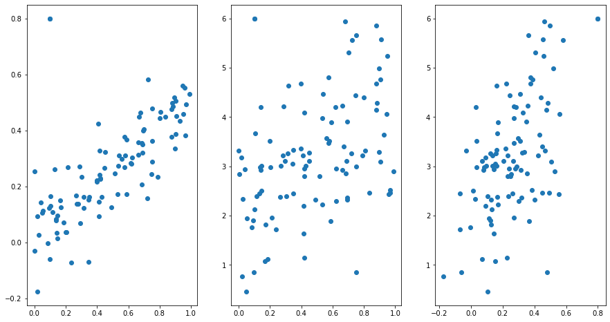

```python
fig, (ax1, ax2, ax3) = plt.subplots(1, 3, figsize=(15,8))
ax1.scatter(df_14.x1, df_14.x2)
ax2.scatter(df_14.x1, df_14.y)
ax3.scatter(df_14.x2, df_14.y)
plt.show()
```

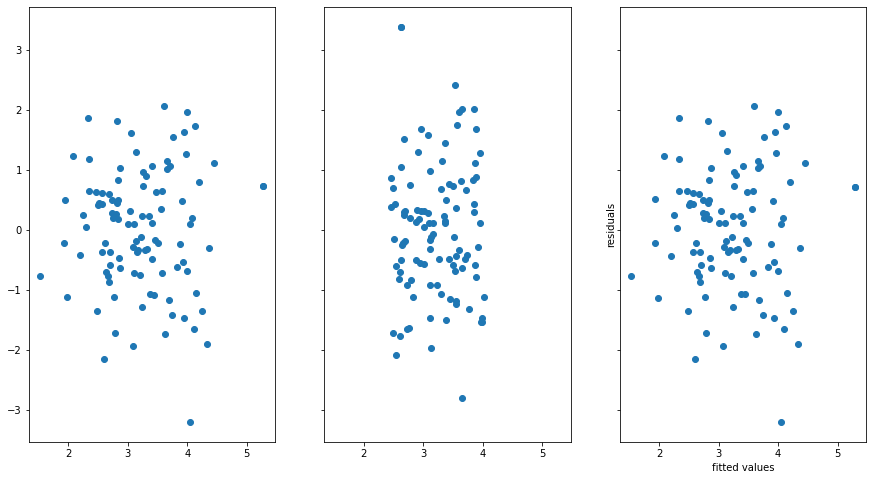

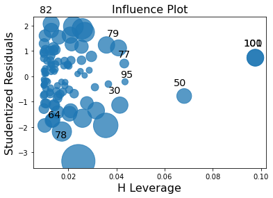

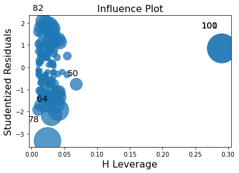

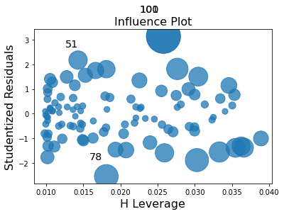

[figure not shown]

```python
fig, (ax1, ax2, ax3) = plt.subplots(1, 3, figsize=(15,8), sharex=True, sharey=True)
ax1.scatter(fourteen_g_model.fittedvalues, fourteen_g_model.resid)
ax2.scatter(fourteen_g_x1model.fittedvalues, fourteen_g_x1model.resid)
ax3.scatter(fourteen_g_x2model.fittedvalues, fourteen_g_x2model.resid)
plt.xlabel('fitted values')
plt.ylabel('residuals')
plt.show()

sm.graphics.influence_plot(fourteen_g_model)
sm.graphics.influence_plot(fourteen_g_x1model)
sm.graphics.influence_plot(fourteen_g_x2model)
```

> Which confirms that the new data point 101 has a high leverage.

# 15. Predicting Crime Rate in Boston

This problem involves the Boston data set, which we saw in the lab for this chapter. We will now try to predict per capita crime rate using the other variables in this data set. In other words, per capita crime rate is the response, and the other variables are the predictors.

**15.(a)** For each predictor, fit a simple linear regression model to predict the response. Describe your results. In which of the models is there a statistically significant association between the predictor and the response? Create some plots to back up your assertions.

```python
Boston_df = pd.read_csv('~/.../Data/BostonHousing.csv')
Boston_df.tail()
```

|  | crim | zn | indus | chas | nox | rm | age | dis | rad | tax | ptratio | b | lstat | medv |
| --- | --- | --- | --- | --- | --- | --- | --- | --- | --- | --- | --- | --- | --- | --- |
| 501 | 0.06263 | 0.0 | 11.93 | 0 | 0.573 | 6.593 | 69.1 | 2.4786 | 1 | 273 | 21.0 | 391.99 | 9.67 | 22.4 |
| 502 | 0.04527 | 0.0 | 11.93 | 0 | 0.573 | 6.120 | 76.7 | 2.2875 | 1 | 273 | 21.0 | 396.90 | 9.08 | 20.6 |
| 503 | 0.06076 | 0.0 | 11.93 | 0 | 0.573 | 6.976 | 91.0 | 2.1675 | 1 | 273 | 21.0 | 396.90 | 5.64 | 23.9 |
| 504 | 0.10959 | 0.0 | 11.93 | 0 | 0.573 | 6.794 | 89.3 | 2.3889 | 1 | 273 | 21.0 | 393.45 | 6.48 | 22.0 |
| 505 | 0.04741 | 0.0 | 11.93 | 0 | 0.573 | 6.030 | 80.8 | 2.5050 | 1 | 273 | 21.0 | 396.90 | 7.88 | 11.9 |

> Lets first check if there are any missing data in any of the variables.

```python
Boston_df.isnull().sum()
```

```
crim       0
zn         0
indus      0
chas       0
nox        0
rm         0
age        0
dis        0
rad        0
tax        0
ptratio    0
b          0
lstat      0
medv       0
dtype: int64
```

> To run a simple regression for each predictor we can write a function instead of doing each one separately.  
> For this we will use the R-style syntax from statsmodels.functions.api as smf to avoid forgetting to add a constant, just in case. The format is: smf.ols(formula, data, subset=None, drop_cols=None, args, kwargs)  
> So the formula will be crime on an empty dictionary and we will use the format function to populate that dictionary one at time using a for loop. We will then put this into a list using [ ].

```python
fifteen_a_models = [smf.ols('crim ~ {}'.format(x), data = Boston_df).fit() for x in Boston_df.columns[1:]]
fifteen_a_models
```

```
[<statsmodels.regression.linear_model.RegressionResultsWrapper at 0x7f7f2841c7c0>,
 <statsmodels.regression.linear_model.RegressionResultsWrapper at 0x7f7f2785f790>,
 <statsmodels.regression.linear_model.RegressionResultsWrapper at 0x7f7f2785ff10>,
 <statsmodels.regression.linear_model.RegressionResultsWrapper at 0x7f7f2786ce50>,
 <statsmodels.regression.linear_model.RegressionResultsWrapper at 0x7f7f2786c550>,
 <statsmodels.regression.linear_model.RegressionResultsWrapper at 0x7f7f278740d0>,
 <statsmodels.regression.linear_model.RegressionResultsWrapper at 0x7f7f2777f910>,
 <statsmodels.regression.linear_model.RegressionResultsWrapper at 0x7f7f2778bac0>,
 <statsmodels.regression.linear_model.RegressionResultsWrapper at 0x7f7f2778baf0>,
 <statsmodels.regression.linear_model.RegressionResultsWrapper at 0x7f7f27783b20>,
 <statsmodels.regression.linear_model.RegressionResultsWrapper at 0x7f7f27783040>,
 <statsmodels.regression.linear_model.RegressionResultsWrapper at 0x7f7f277916d0>,
 <statsmodels.regression.linear_model.RegressionResultsWrapper at 0x7f7f27791af0>]
```

> So at this stage all we are getting is a list of statsmodels regression results wrapper. We will need to get the relevant outputs we want (in this case these are the coefficients, standard errors, t-values, p-values, and the 95% CI) into a data frame so we can see the results. We will again use a for loop. Since we don't need the intercept results we will only get the rows of the variables using [1:]:

```python
for x in fifteen_a_models:
    display(pd.DataFrame({'coef': x.params[1:], 'std err': x.bse[1:], 't': x.params[1:]/x.bse[1:], 'P>|t|': x.pvalues[1:],
                          }))
```

|  | coef | std err | t | P>\|t\| |
| --- | --- | --- | --- | --- |
| zn | -0.073935 | 0.016095 | -4.593776 | 0.000006 |

|  | coef | std err | t | P>\|t\| |
| --- | --- | --- | --- | --- |
| indus | 0.509776 | 0.051024 | 9.990848 | 1.450349e-21 |

|  | coef | std err | t | P>\|t\| |
| --- | --- | --- | --- | --- |
| chas | -1.892777 | 1.506115 | -1.256727 | 0.209435 |

|  | coef | std err | t | P>\|t\| |
| --- | --- | --- | --- | --- |
| nox | 31.248531 | 2.99919 | 10.418989 | 3.751739e-23 |

|  | coef | std err | t | P>\|t\| |
| --- | --- | --- | --- | --- |
| rm | -2.684051 | 0.532041 | -5.044819 | 6.346703e-07 |

|  | coef | std err | t | P>\|t\| |
| --- | --- | --- | --- | --- |
| age | 0.107786 | 0.012736 | 8.462825 | 2.854869e-16 |

|  | coef | std err | t | P>\|t\| |
| --- | --- | --- | --- | --- |
| dis | -1.550902 | 0.16833 | -9.213458 | 8.519949e-19 |

|  | coef | std err | t | P>\|t\| |
| --- | --- | --- | --- | --- |
| rad | 0.617911 | 0.034332 | 17.998199 | 2.693844e-56 |

|  | coef | std err | t | P>\|t\| |
| --- | --- | --- | --- | --- |
| tax | 0.029742 | 0.001847 | 16.099388 | 2.357127e-47 |

|  | coef | std err | t | P>\|t\| |
| --- | --- | --- | --- | --- |
| ptratio | 1.151983 | 0.169374 | 6.80143 | 2.942922e-11 |

|  | coef | std err | t | P>\|t\| |
| --- | --- | --- | --- | --- |
| b | -0.03628 | 0.003873 | -9.366951 | 2.487274e-19 |

|  | coef | std err | t | P>\|t\| |
| --- | --- | --- | --- | --- |
| lstat | 0.548805 | 0.047761 | 11.490654 | 2.654277e-27 |

|  | coef | std err | t | P>\|t\| |
| --- | --- | --- | --- | --- |
| medv | -0.36316 | 0.03839 | -9.45971 | 1.173987e-19 |

> We can see from the dataframe we created that when we regress crime rates on each variable indivudally, only the proximity to Charles River (ie chas dummy) is not significant.

**15.(b)** Fit a multiple regression model to predict the response using all of the predictors. Describe your results. For which predictors can we reject the null hypothesis $H_0 : \beta_j = 0$?

> Note that we can put together all the columns as predictors instead of writing them out individually by:  
> Bostoncrim_predictors = Boston_df.columns.drop('crim')  
> predictors = ' + '.join(Bostoncrim_predictors)  
> reg = '{} ~ {}'.format('crim', predictors)  
> print(smf.ols(formula=reg, data=Boston_df).fit().summary())  
> I opted for writing them out individually but both will approches will give the same result:

```python
fifteen_b_model = smf.ols('crim ~ zn + indus + chas + nox + rm + age + dis + rad + tax + ptratio + b + lstat + medv', data=Boston_df).fit()
print(fifteen_b_model.summary())
```

```
                            OLS Regression Results
==============================================================================
Dep. Variable:                   crim   R-squared:                       0.454
Model:                            OLS   Adj. R-squared:                  0.440
Method:                 Least Squares   F-statistic:                     31.47
Date:                Mon, 25 Jan 2021   Prob (F-statistic):           1.57e-56
Time:                        12:07:48   Log-Likelihood:                -1653.3
No. Observations:                 506   AIC:                             3335.
Df Residuals:                     492   BIC:                             3394.
Df Model:                          13
Covariance Type:            nonrobust
==============================================================================
                 coef    std err          t      P>|t|      [0.025      0.975]
------------------------------------------------------------------------------
Intercept     17.0332      7.235      2.354      0.019       2.818      31.248
zn             0.0449      0.019      2.394      0.017       0.008       0.082
indus         -0.0639      0.083     -0.766      0.444      -0.228       0.100
chas          -0.7491      1.180     -0.635      0.526      -3.068       1.570
nox          -10.3135      5.276     -1.955      0.051     -20.679       0.052
rm             0.4301      0.613      0.702      0.483      -0.774       1.634
age            0.0015      0.018      0.081      0.935      -0.034       0.037
dis           -0.9872      0.282     -3.503      0.001      -1.541      -0.433
rad            0.5882      0.088      6.680      0.000       0.415       0.761
tax           -0.0038      0.005     -0.733      0.464      -0.014       0.006
ptratio       -0.2711      0.186     -1.454      0.147      -0.637       0.095
b             -0.0075      0.004     -2.052      0.041      -0.015      -0.000
lstat          0.1262      0.076      1.667      0.096      -0.023       0.275
medv          -0.1989      0.061     -3.287      0.001      -0.318      -0.080
==============================================================================
Omnibus:                      666.613   Durbin-Watson:                   1.519
Prob(Omnibus):                  0.000   Jarque-Bera (JB):            84887.625
Skew:                           6.617   Prob(JB):                         0.00
Kurtosis:                      65.058   Cond. No.                     1.58e+04
==============================================================================

Notes:
[1] Standard Errors assume that the covariance matrix of the errors is correctly specified.
[2] The condition number is large, 1.58e+04. This might indicate that there are
strong multicollinearity or other numerical problems.
```

> From the F-stat and its p-value we can see that at least one predictor is non-zero. We can see that the weighted mean of distances to five Boston employment centres and the index of accessibility to radial highways are statistically significant, so we can reject the null that the coefficients for these are 0. We also see that the p-value for the median value of owner-occupied homes is just above 0.001, it will be statistically significant at p-value = 0.0011 or above. The proportion of black people in town and the proportion of residential land zones for lots over 25,000 sq.ft. are only statistically significant at 0.05 cut-off. Finally, nitrogen oxide concentration and lower status of the population are statistically significant only at 0.1 cut-off.

**15.(c)** How do your results from (a) compare to your results from (b)? Create a plot displaying the univariate regression coefficients from (a) on the x-axis, and the multiple regression coefficients from (b) on the y-axis. That is, each predictor is displayed as a single point in the plot. Its coefficient in a simple linear regression model is shown on the x-axis, and its coefficient estimate in the multiple linear regression model is shown on the y-axis.

> First lets get all the coefficients from (a) and (b) into a dataframe:

```python
fifteen_a_params = pd.concat([x.params[1:] for x in fifteen_a_models])
fifteen_b_params = fifteen_b_model.params[1:]
fifteen_df = pd.DataFrame({'Univariate Coeff': fifteen_a_params, 'Multivariate Coeff': fifteen_b_params})
fifteen_df
```

|  | Univariate Coeff | Multivariate Coeff |
| --- | --- | --- |
| zn | -0.073935 | 0.044855 |
| indus | 0.509776 | -0.063855 |
| chas | -1.892777 | -0.749134 |
| nox | 31.248531 | -10.313535 |
| rm | -2.684051 | 0.430131 |
| age | 0.107786 | 0.001452 |
| dis | -1.550902 | -0.987176 |
| rad | 0.617911 | 0.588209 |
| tax | 0.029742 | -0.003780 |
| ptratio | 1.151983 | -0.271081 |
| b | -0.036280 | -0.007538 |
| lstat | 0.548805 | 0.126211 |
| medv | -0.363160 | -0.198887 |

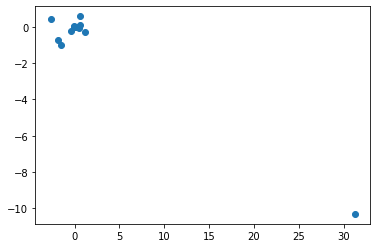

```python
plt.scatter(fifteen_df['Univariate Coeff'], fifteen_df['Multivariate Coeff'])
plt.show()
```

**15.(d)** Is there evidence of non-linear association between any of the predictors and the response? To answer this question, for each predictor X, fit a model of the form

$Y = \beta_0 + \beta_1X + \beta_2X^2 + \beta_3X^3 + \varepsilon$

> For this we need to modify our loop in (a)

```python
fifteen_d_models = [smf.ols('crim ~ {0} + np.power({0}, 2) + np.power({0}, 3)'.format(x), data = Boston_df).fit()
                    for x in Boston_df.columns[1:]]
for x in fifteen_a_models:
    display(pd.DataFrame({'coef': x.params[1:], 'std err': x.bse[1:], 't': x.params[1:]/x.bse[1:], 'P>|t|': x.pvalues[1:],
                          }))
```

[output not shown]

|  | coef | std err | t | P>\|t\| |
| --- | --- | --- | --- | --- |
| zn | -0.073935 | 0.016095 | -4.593776 | 0.000006 |

|  | coef | std err | t | P>\|t\| |
| --- | --- | --- | --- | --- |
| indus | 0.509776 | 0.051024 | 9.990848 | 1.450349e-21 |

|  | coef | std err | t | P>\|t\| |
| --- | --- | --- | --- | --- |
| chas | -1.892777 | 1.506115 | -1.256727 | 0.209435 |

|  | coef | std err | t | P>\|t\| |
| --- | --- | --- | --- | --- |
| nox | 31.248531 | 2.99919 | 10.418989 | 3.751739e-23 |

|  | coef | std err | t | P>\|t\| |
| --- | --- | --- | --- | --- |
| rm | -2.684051 | 0.532041 | -5.044819 | 6.346703e-07 |

|  | coef | std err | t | P>\|t\| |
| --- | --- | --- | --- | --- |
| age | 0.107786 | 0.012736 | 8.462825 | 2.854869e-16 |

|  | coef | std err | t | P>\|t\| |
| --- | --- | --- | --- | --- |
| dis | -1.550902 | 0.16833 | -9.213458 | 8.519949e-19 |

|  | coef | std err | t | P>\|t\| |
| --- | --- | --- | --- | --- |
| rad | 0.617911 | 0.034332 | 17.998199 | 2.693844e-56 |

|  | coef | std err | t | P>\|t\| |
| --- | --- | --- | --- | --- |
| tax | 0.029742 | 0.001847 | 16.099388 | 2.357127e-47 |

|  | coef | std err | t | P>\|t\| |
| --- | --- | --- | --- | --- |
| ptratio | 1.151983 | 0.169374 | 6.80143 | 2.942922e-11 |

|  | coef | std err | t | P>\|t\| |
| --- | --- | --- | --- | --- |
| b | -0.03628 | 0.003873 | -9.366951 | 2.487274e-19 |

|  | coef | std err | t | P>\|t\| |
| --- | --- | --- | --- | --- |
| lstat | 0.548805 | 0.047761 | 11.490654 | 2.654277e-27 |

|  | coef | std err | t | P>\|t\| |
| --- | --- | --- | --- | --- |
| medv | -0.36316 | 0.03839 | -9.45971 | 1.173987e-19 |

# [Home](https://e-usenmez.github.io/ISL/)